# 1 Abstract

### 3.3.2 Read Data

Due to the files preload all before simulate the statistical modelling will occupy the space. Here I directly read the files and simulate the algorithmic prediction in following sections.

```r
rm(list = ls()[grep('i|j|tz|nch|yw|dtm|dttm|form|data|Y2015W|tsz|tsz2|dc', ls())])

cr_code <- c('AUDUSD=X', 'EURUSD=X', 'GBPUSD=X', 'CHF=X', 'CAD=X', 'CNY=X', 'JPY=X')

names(cr_code) <- c('AUDUSD', 'EURUSD', 'GBPUSD', 'USDCHF', 'USDCAD', 'USDCNY', 'USDJPY')

data_m1 <- read_rds(paste0(dtr1s, '/data_m1.rds'))

tb1 <- data_m1 %>% ddply(.(year, week), head, 1) %>%
  kbl('html', caption = 'Weekly Initial Data Point', escape = FALSE) %>%
  kable_styling(bootstrap_options = c('striped', 'hover', 'condensed', 'responsive')) %>%
  scroll_box(width = '100%', height = '400px')

tb1
```

Weekly Initial Data Point

| index | year | week | BidOpen | BidHigh | BidLow | BidClose | AskOpen | AskHigh | AskLow | AskClose |
| --- | --- | --- | --- | --- | --- | --- | --- | --- | --- | --- |
| 2015-01-05 00:01:00 | 2015 | 1 | 120.502 | 120.570 | 120.484 | 120.538 | 120.608 | 120.671 | 120.566 | 120.610 |
| 2015-01-12 00:01:00 | 2015 | 2 | 118.222 | 118.280 | 118.214 | 118.262 | 118.276 | 118.312 | 118.258 | 118.282 |
| 2015-01-19 00:01:00 | 2015 | 3 | 117.442 | 117.442 | 117.402 | 117.432 | 117.478 | 117.550 | 117.478 | 117.512 |
| 2015-01-26 00:01:00 | 2015 | 4 | 117.500 | 117.504 | 117.467 | 117.482 | 117.508 | 117.524 | 117.502 | 117.507 |
| 2015-02-02 00:01:00 | 2015 | 5 | 116.979 | 117.048 | 116.971 | 117.046 | 117.011 | 117.067 | 116.983 | 117.065 |
| 2015-02-09 00:01:00 | 2015 | 6 | 119.028 | 119.046 | 119.000 | 119.046 | 119.081 | 119.150 | 119.042 | 119.052 |
| 2015-02-16 00:01:00 | 2015 | 7 | 118.562 | 118.628 | 118.544 | 118.628 | 118.587 | 118.649 | 118.548 | 118.646 |
| 2015-02-23 00:01:00 | 2015 | 8 | 119.094 | 119.094 | 119.061 | 119.061 | 119.149 | 119.149 | 119.109 | 119.109 |
| 2015-03-02 00:01:00 | 2015 | 9 | 119.688 | 119.716 | 119.673 | 119.716 | 119.760 | 119.764 | 119.714 | 119.748 |
| 2015-03-09 00:01:00 | 2015 | 10 | 120.800 | 120.836 | 120.800 | 120.836 | 120.920 | 120.920 | 120.889 | 120.889 |
| 2015-03-16 00:01:00 | 2015 | 11 | 121.374 | 121.382 | 121.346 | 121.346 | 121.430 | 121.436 | 121.410 | 121.410 |
| 2015-03-23 00:01:00 | 2015 | 12 | 119.884 | 119.894 | 119.868 | 119.890 | 119.900 | 119.902 | 119.897 | 119.898 |
| 2015-03-30 00:01:00 | 2015 | 13 | 119.216 | 119.220 | 119.203 | 119.203 | 119.247 | 119.253 | 119.230 | 119.230 |
| 2015-04-06 00:01:00 | 2015 | 14 | 118.845 | 118.845 | 118.839 | 118.839 | 118.915 | 118.951 | 118.915 | 118.943 |
| 2015-04-13 00:01:00 | 2015 | 15 | 120.299 | 120.311 | 120.299 | 120.311 | 120.385 | 120.386 | 120.368 | 120.368 |
| 2015-04-20 00:01:00 | 2015 | 16 | 118.985 | 118.993 | 118.985 | 118.993 | 119.014 | 119.047 | 119.014 | 119.047 |
| 2015-04-27 00:01:00 | 2015 | 17 | 118.864 | 118.877 | 118.864 | 118.876 | 118.906 | 118.906 | 118.903 | 118.903 |
| 2015-05-04 00:01:00 | 2015 | 18 | 120.227 | 120.227 | 120.226 | 120.226 | 120.242 | 120.242 | 120.242 | 120.242 |
| 2015-05-11 00:01:00 | 2015 | 19 | 119.652 | 119.688 | 119.644 | 119.658 | 119.684 | 119.731 | 119.676 | 119.719 |
| 2015-05-18 00:01:00 | 2015 | 20 | 119.214 | 119.255 | 119.214 | 119.255 | 119.308 | 119.314 | 119.308 | 119.312 |
| 2015-05-25 00:01:00 | 2015 | 21 | 121.494 | 121.494 | 121.488 | 121.488 | 121.516 | 121.516 | 121.512 | 121.512 |
| 2015-06-01 00:01:00 | 2015 | 22 | 124.076 | 124.084 | 124.072 | 124.072 | 124.100 | 124.106 | 124.094 | 124.096 |
| 2015-06-08 00:01:00 | 2015 | 23 | 125.578 | 125.588 | 125.566 | 125.568 | 125.598 | 125.610 | 125.590 | 125.590 |
| 2015-06-15 00:01:00 | 2015 | 24 | 123.174 | 123.174 | 123.130 | 123.159 | 123.276 | 123.276 | 123.186 | 123.189 |
| 2015-06-22 00:01:00 | 2015 | 25 | 122.955 | 122.957 | 122.922 | 122.922 | 122.968 | 122.968 | 122.936 | 122.936 |
| 2015-06-29 00:01:00 | 2015 | 26 | 122.728 | 122.736 | 122.667 | 122.707 | 122.740 | 122.806 | 122.692 | 122.740 |
| 2015-07-06 00:01:00 | 2015 | 27 | 121.968 | 122.004 | 121.951 | 121.986 | 121.992 | 122.128 | 121.978 | 122.002 |
| 2015-07-13 00:01:00 | 2015 | 28 | 122.218 | 122.224 | 122.178 | 122.204 | 122.332 | 122.332 | 122.206 | 122.286 |
| 2015-07-20 00:01:00 | 2015 | 29 | 124.044 | 124.044 | 124.036 | 124.036 | 124.058 | 124.058 | 124.048 | 124.048 |
| 2015-07-27 00:01:00 | 2015 | 30 | 123.728 | 123.760 | 123.726 | 123.760 | 123.800 | 123.830 | 123.770 | 123.830 |

[output cut: 154 more lines]

```r
tb2 <- data_m1 %>% ddply(.(year, week), tail, 1) %>%
  kbl('html', caption = 'Weekly Final Data Point', escape = FALSE) %>%
  kable_styling(bootstrap_options = c('striped', 'hover', 'condensed', 'responsive')) %>%
  scroll_box(width = '100%', height = '400px')

tb2
```

Weekly Final Data Point

| index | year | week | BidOpen | BidHigh | BidLow | BidClose | AskOpen | AskHigh | AskLow | AskClose |
| --- | --- | --- | --- | --- | --- | --- | --- | --- | --- | --- |
| 2015-01-10 | 2015 | 1 | 118.522 | 118.522 | 118.495 | 118.495 | 118.556 | 118.601 | 118.556 | 118.601 |
| 2015-01-17 | 2015 | 2 | 117.462 | 117.554 | 117.461 | 117.548 | 117.490 | 117.669 | 117.482 | 117.669 |
| 2015-01-24 | 2015 | 3 | 117.724 | 117.770 | 117.714 | 117.732 | 117.834 | 117.836 | 117.796 | 117.816 |
| 2015-01-31 | 2015 | 4 | 117.493 | 117.534 | 117.438 | 117.528 | 117.548 | 117.614 | 117.548 | 117.576 |
| 2015-02-07 | 2015 | 5 | 119.134 | 119.134 | 119.090 | 119.090 | 119.158 | 119.222 | 119.158 | 119.222 |
| 2015-02-14 | 2015 | 6 | 118.719 | 118.719 | 118.696 | 118.696 | 118.919 | 118.944 | 118.919 | 118.944 |
| 2015-02-21 | 2015 | 7 | 119.050 | 119.056 | 118.966 | 119.010 | 119.098 | 119.116 | 119.036 | 119.042 |
| 2015-02-28 | 2015 | 8 | 119.596 | 119.636 | 119.576 | 119.576 | 119.620 | 119.710 | 119.618 | 119.704 |
| 2015-03-07 | 2015 | 9 | 120.784 | 120.784 | 120.708 | 120.708 | 120.804 | 120.885 | 120.804 | 120.885 |
| 2015-03-14 | 2015 | 10 | 121.426 | 121.428 | 121.350 | 121.416 | 121.448 | 121.496 | 121.388 | 121.458 |
| 2015-03-21 | 2015 | 11 | 120.048 | 120.052 | 120.008 | 120.018 | 120.072 | 120.100 | 120.056 | 120.068 |
| 2015-03-28 | 2015 | 12 | 119.112 | 119.112 | 119.109 | 119.109 | 119.150 | 119.171 | 119.150 | 119.171 |
| 2015-04-04 | 2015 | 13 | 118.929 | 118.929 | 118.928 | 118.928 | 119.016 | 119.041 | 119.016 | 119.041 |
| 2015-04-11 | 2015 | 14 | 120.170 | 120.174 | 120.170 | 120.174 | 120.206 | 120.261 | 120.206 | 120.261 |
| 2015-04-18 | 2015 | 15 | 118.889 | 118.897 | 118.889 | 118.897 | 118.971 | 118.978 | 118.971 | 118.978 |
| 2015-04-25 | 2015 | 16 | 118.906 | 118.930 | 118.906 | 118.926 | 118.974 | 119.020 | 118.974 | 119.015 |
| 2015-05-02 | 2015 | 17 | 120.202 | 120.202 | 120.171 | 120.171 | 120.256 | 120.256 | 120.251 | 120.251 |
| 2015-05-09 | 2015 | 18 | 119.754 | 119.771 | 119.754 | 119.771 | 119.806 | 119.870 | 119.806 | 119.870 |
| 2015-05-16 | 2015 | 19 | 119.366 | 119.366 | 119.352 | 119.359 | 119.418 | 119.467 | 119.418 | 119.450 |
| 2015-05-23 | 2015 | 20 | 121.544 | 121.544 | 121.500 | 121.500 | 121.576 | 121.591 | 121.576 | 121.581 |
| 2015-05-30 | 2015 | 21 | 124.130 | 124.130 | 124.112 | 124.112 | 124.154 | 124.191 | 124.154 | 124.191 |
| 2015-06-06 | 2015 | 22 | 125.577 | 125.588 | 125.575 | 125.576 | 125.638 | 125.667 | 125.638 | 125.655 |
| 2015-06-13 | 2015 | 23 | 123.359 | 123.359 | 123.349 | 123.349 | 123.446 | 123.471 | 123.446 | 123.471 |
| 2015-06-20 | 2015 | 24 | 122.672 | 122.672 | 122.632 | 122.632 | 122.724 | 122.725 | 122.711 | 122.711 |
| 2015-06-27 | 2015 | 25 | 123.884 | 123.884 | 123.809 | 123.809 | 123.912 | 123.926 | 123.901 | 123.901 |
| 2015-07-04 | 2015 | 26 | 122.854 | 122.854 | 122.799 | 122.799 | 122.914 | 122.934 | 122.888 | 122.901 |
| 2015-07-11 | 2015 | 27 | 122.721 | 122.844 | 122.654 | 122.792 | 122.780 | 122.893 | 122.780 | 122.893 |
| 2015-07-18 | 2015 | 28 | 124.075 | 124.088 | 124.020 | 124.054 | 124.103 | 124.126 | 124.070 | 124.078 |
| 2015-07-25 | 2015 | 29 | 123.800 | 123.800 | 123.769 | 123.769 | 123.832 | 123.856 | 123.832 | 123.848 |
| 2015-08-01 | 2015 | 30 | 123.875 | 123.875 | 123.836 | 123.836 | 123.944 | 123.944 | 123.944 | 123.944 |

[output cut: 154 more lines]

```r
## Tidy dataset for modelling.
data_m1 %<>%
  mutate(open = (BidOpen + AskOpen)/2, close = (BidClose + AskClose)/2) %>%
  dplyr::rename(high = BidHigh, low = AskLow) %>%  #use bid price for sell.
  dplyr::select(index, open, high, low, close)     # and ask price for buy.
```

Here I try to check if the filled dataset bias or not. Due to above I used `open = (BidOpen + AskOpen)/2`, `high = BidHigh`, `low = AskLow` and `close = (BidClose + AskClose)/2`[^1]. There will probably have bias.

```r
tb3 <- data_m1 %>% mutate(
  bias.open = if_else(open>high|open<low, 1, 0),
  bias.high = if_else(high<open|high<low|high<close, 1, 0),
  bias.low = if_else(low>open|low>high|low>close, 1, 0),
  bias.close = if_else(close>high|close<low, 1, 0)) %>%
  dplyr::filter(bias.open==1|bias.high==1|bias.low==1|bias.close==1)# %>%
#  kable(caption = 'Bias Imputation') %>%
#  kable_styling(bootstrap_options = c('striped', 'hover', 'condensed', 'responsive')) %>%
#  scroll_box(width = '100%', height = '400px')

tb3
```

```
## # A tibble: 709,076 x 9
##    index                open  high   low close bias.open bias.high bias.low
##    <dttm>              <dbl> <dbl> <dbl> <dbl>     <dbl>     <dbl>    <dbl>
##  1 2015-01-05 00:01:00  121.  121.  121.  121.         1         1        1
##  2 2015-01-05 00:02:00  121.  121.  121.  121.         1         1        1
##  3 2015-01-05 00:04:00  121.  121.  121.  121.         1         1        0
##  4 2015-01-05 00:05:00  121.  121.  121.  121.         1         1        0
##  5 2015-01-05 00:09:00  121.  121.  121.  121.         0         0        1
##  6 2015-01-05 00:10:00  121.  121.  121.  121.         1         1        1
##  7 2015-01-05 00:11:00  121.  121.  121.  121.         1         1        1
##  8 2015-01-05 00:12:00  121.  121.  121.  121.         1         1        1
##  9 2015-01-05 00:13:00  121.  121.  121.  121.         1         1        1
## 10 2015-01-05 00:14:00  121.  121.  121.  121.         0         0        1
## # ... with 709,066 more rows, and 1 more variable: bias.close <dbl>
```

```r
# -------- eval=FALSE -----------
## Below prove that the dataset has no any bias or error.
> read_rds(paste0(dtr1, '/data_m1.rds')) %>% mutate(
+     open = BidOpen, high = BidHigh, low = BidLow, close = BidClose,
+     bias.open = if_else(open>high|open<low, 1, 0),
+     bias.high = if_else(high<open|high<low|high<close, 1, 0),
+     bias.low = if_else(low>open|low>high|low>close, 1, 0),
+     bias.close = if_else(close>high|close<low, 1, 0)) %>%
+     dplyr::filter(bias.open==1|bias.high==1|bias.low==1|bias.close==1)
# A tibble: 0 x 19
# ... with 19 variables: index <dttm>, year <dbl>, week <dbl>, BidOpen <dbl>, BidHigh <dbl>, BidLow <dbl>,
#   BidClose <dbl>, AskOpen <dbl>, AskHigh <dbl>, AskLow <dbl>, AskClose <dbl>, open <dbl>, high <dbl>, low <dbl>,
#   close <dbl>, bias.open <dbl>, bias.high <dbl>, bias.low <dbl>, bias.close <dbl>

> read_rds(paste0(dtr, '/data_tm1.rds')) %>% mutate(
+     open = BidOpen, high = BidHigh, low = BidLow, close = BidClose,
+     bias.open = if_else(open>high|open<low, 1, 0),
+     bias.high = if_else(high<open|high<low|high<close, 1, 0),
+     bias.low = if_else(low>open|low>high|low>close, 1, 0),
+     bias.close = if_else(close>high|close<low, 1, 0)) %>%
+     dplyr::filter(bias.open==1|bias.high==1|bias.low==1|bias.close==1)
# A tibble: 0 x 19
# ... with 19 variables: index <dttm>, year <dbl>, week <dbl>, AskOpen <dbl>, AskHigh <dbl>, AskLow <dbl>,
#   AskClose <dbl>, BidOpen <dbl>, BidHigh <dbl>, BidLow <dbl>, BidClose <dbl>, open <dbl>, high <dbl>, low <dbl>,
#   close <dbl>, bias.open <dbl>, bias.high <dbl>, bias.low <dbl>, bias.close <dbl>

> read_rds(paste0(dtr1, '/data_m1.rds')) %>% mutate(
+     open = AskOpen, high = AskHigh, low = AskLow, close = AskClose,
+     bias.open = if_else(open>high|open<low, 1, 0),
+     bias.high = if_else(high<open|high<low|high<close, 1, 0),
+     bias.low = if_else(low>open|low>high|low>close, 1, 0),
+     bias.close = if_else(close>high|close<low, 1, 0)) %>%
+     dplyr::filter(bias.open==1|bias.high==1|bias.low==1|bias.close==1)
# A tibble: 0 x 19
# ... with 19 variables: index <dttm>, year <dbl>, week <dbl>, BidOpen <dbl>, BidHigh <dbl>, BidLow <dbl>,
#   BidClose <dbl>, AskOpen <dbl>, AskHigh <dbl>, AskLow <dbl>, AskClose <dbl>, open <dbl>, high <dbl>, low <dbl>,
#   close <dbl>, bias.open <dbl>, bias.high <dbl>, bias.low <dbl>, bias.close <dbl>

> read_rds(dtr1, paste0('/data_tm1.rds')) %>% mutate(
+     open = AskOpen, high = AskHigh, low = AskLow, close = AskClose,
+     bias.open = if_else(open>high|open<low, 1, 0),
+     bias.high = if_else(high<open|high<low|high<close, 1, 0),
+     bias.low = if_else(low>open|low>high|low>close, 1, 0),
+     bias.close = if_else(close>high|close<low, 1, 0)) %>%
+     dplyr::filter(bias.open==1|bias.high==1|bias.low==1|bias.close==1)
# A tibble: 0 x 19
# ... with 19 variables: index <dttm>, year <dbl>, week <dbl>, AskOpen <dbl>, AskHigh <dbl>, AskLow <dbl>,
#   AskClose <dbl>, BidOpen <dbl>, BidHigh <dbl>, BidLow <dbl>, BidClose <dbl>, open <dbl>, high <dbl>, low <dbl>,
#   close <dbl>, bias.open <dbl>, bias.high <dbl>, bias.low <dbl>, bias.close <dbl>
```

I initially try to use `bid` for high and `ask` for low in order to produce a better prediction price for buy and sell. However, I use the mean value of OHLC all prices for this paper to avoid the statistical error/bias.

Due to `1min` dataset is better than (more complete) `tickdata-to-1min`, here I use the `1min` dataset.

```r
if(!exists('data_m1')) {
  data_m1 <- read_rds(paste0(dtr1s, '/data_m1.rds'))
}
if(names(data_m1) %>% str_detect('Bid|Ask') %>% any()) {
data_m1 %<>%
  mutate(open = (BidOpen + AskOpen)/2,
         high = (BidHigh + AskHigh)/2,
         low = (BidLow + AskLow)/2,
         close = (BidClose + AskClose)/2) %>%
  dplyr::select(index, open, high, low, close)
}
```

```r
tb4 <- data_m1 %>% mutate(
  bias.open = if_else(open>high|open<low, 1, 0),
  bias.high = if_else(high<open|high<low|high<close, 1, 0),
  bias.low = if_else(low>open|low>high|low>close, 1, 0),
  bias.close = if_else(close>high|close<low, 1, 0)) %>%
  dplyr::filter(bias.open==1|bias.high==1|bias.low==1|bias.close==1)# %>%
#  kable(caption = 'Bias Imputation') %>%
#  kable_styling(bootstrap_options = c('striped', 'hover', 'condensed', 'responsive')) %>%
#  scroll_box(width = '100%', height = '400px')

tb4
```

[output not shown]

```javascript
//<script type="text/javascript" src="//cdn.datacamp.com/dcl-react.js.gz"></script>
```

*Source : [DataCamp Light](https://github.com/datacamp/datacamp-light)*

You are feel free to surf [Online Coding Platform Example](https://cdn.datacamp.com/dcl-react-prod/example.html) for R, Python and also Shell.

# 4 Modelling

## 4.1 Seasonal Modelling

Below articles introduce **TBATS models** `tbats()` and **Dynamic harmonic regression with multiple seasonal periods** `auto.arima()`. Here I also includes `ts()`, **MIDAS** `midasr()`, **GARCH-MIDAS**, **mcsGARCH** and **Levy Process** for this research.

- [Forecasting: Principles and Practice - *11.1 Complex seasonality*](https://otexts.com/fpp2/complexseasonality.html#complexseasonality)
- [Forecasting: Principles and Practice - *12.1 Weekly, daily and sub-daily data*](https://otexts.com/fpp2/weekly.html#weekly)

**Progress Function**

```r
task_progress <- function(mbase, timeID0 = NULL, scs = 60, .pattern = '^mts|^sets', .loops = TRUE) {
  ## ------------- 定时查询进度 ----------------------
  ## 每分钟自动查询与更新以上模拟预测汇价进度（储存文件量）。
  require('magrittr')
  require('tibble')

  if(!is.data.frame(class(mbase))) {
    mbase %<>% data.frame
  }

  if (.loops == TRUE) {
    while(1) {
      cat('Current Tokyo Time :', as.character(now('Asia/Tokyo')), '\n\n')

      y = as_date(mbase$index) %>%
            unique
      y <- y[weekdays(y) != 'Saturday'] #filter and omit the weekly last price which is 12:00am on saturday
        datee = y

        if(is.null(timeID0)) {
            timeID0 = y[1]
        } else if (is.Date(timeID0)) {
            timeID0 = as_date(timeID0)
        } else {
            timeID0 = as_date(mbase$index) %>%
            unique
        }

        y = y[y >= timeID0]

      x = list.files(paste0('./data/fx/USDJPY/'), pattern = .pattern) %>%
          str_replace_all('.rds', '') %>%
          str_replace_all('.201', '_201') %>%
          str_split_fixed('_', '2') %>%
          as_tibble %>%
          dplyr::rename('Model' = 'V1', 'Date' = 'V2') %>%
          mutate(Model = factor(Model), Date = as_date(Date))

      x = join(tibble(Date = datee), x) %>%
          as_tibble
      x %<>% na.omit

      x %<>% mutate(binary = if_else(is.na(Model), 0, 1)) %>%
          spread(Model, binary)

      z <- ldply(x[,-1], function(zz) {
          na.omit(zz) %>% length }) %>%
          dplyr::rename(x = V1) %>%
          mutate(n = length(y), progress = percent(x/n))

      print(z)

      prg = sum(z$x)/sum(z$n)
      cat('\n================', as.character(percent(prg)), '================\n\n')

      if (prg == 1) break #倘若进度达到100%就停止更新。

      Sys.sleep(scs) #以上ldply()耗时3~5秒，而休息时间60秒。
    }
  } else {

    cat('Current Tokyo Time :', as.character(now('Asia/Tokyo')), '\n\n')


      y = as_date(mbase$index) %>%
            unique
      datee = y

      if(is.null(timeID0)) {
          timeID0 = y[1]
      } else if (is.Date(timeID0)) {
          timeID0 = as_date(timeID0)
      } else {
          timeID0 = as_date(mbase$index) %>%
          unique
      }

      y = y[y >= timeID0]

      x = list.files(paste0('./data/fx/USDJPY/'), pattern = .pattern) %>%
          str_replace_all('.rds', '') %>%
          str_replace_all('.201', '_201') %>%
          str_split_fixed('_', '2') %>%
          as_tibble %>%
          dplyr::rename('Model' = 'V1', 'Date' = 'V2') %>%
          mutate(Model = factor(Model), Date = as_date(Date))

      x = join(tibble(Date = datee), x) %>%
          as_tibble
      x %<>% na.omit

      x %<>% mutate(binary = if_else(is.na(Model), 0, 1)) %>%
          spread(Model, binary)

      z <- ldply(x[,-1], function(zz) {
          na.omit(zz) %>% length }) %>%
          dplyr::rename(x = V1) %>%
          mutate(n = length(y), progress = percent(x/n))

    print(z)

    prg = sum(z$x)/sum(z$n)
    cat('\n================', as.character(percent(prg)), '================\n\n')
    }
  }
```

## 4.2 Seasonal ETS

### 4.2.1 ETS `ts()`

The `forecast.ets()` will automatically use the optimal `ets()` which is similar theory with `auto.arima()`.

### 4.2.2 Weekly >> Daily

I set the length of dataset as weekly but the frequency set as 1440 minutes (per day).

```r
# --------- eval=FALSE ---------
#sq <- seq(1 , length(data_m1$index), by = 1440)
#sets <- list()
timeID <- data_m1$index %>%
  as_date %>%
  unique %>%
  sort
timeID %<>% .[. > as_date('2015-01-11')]

for (dt in timeID) {
  smp <- data_m1 %>%
    tk_xts(silent = TRUE)
  dt %<>% as_date
  smp <- smp[paste0(dt %m-% weeks(1) + seconds(59), '/', dt + seconds(59))]

  sets <- smp %>%
    tk_ts(frequency = 1440) %>%
    forecast(h = 1440) %>%
    llply(tk_tbl)

  if(is.double(sets$forecast$index[1])){
    sq <- smp %>%
      tail(1) %>%
      index
    if(weekdays(sq) == '土曜日'|weekdays(sq) == 'Saturday') sq <- sq + days(2)
    sq <- seq(from = sq + minutes(1), sq + days(1), by = 'min')
    sets$forecast$index <- sq

  } else {
    sets$forecast$index <- data_m1$index[
    (which(data_m1$index == smp %>%
             index %>%
             xts::last()) + 1):(
     which(data_m1$index == smp %>%
             index %>%
             xts::last()) + 1440)]
  }

  if (!dir.exists(paste0('data/fx/USDJPY')))
    dir.create(paste0('data/fx/USDJPY'))

  saveRDS(sets, paste0('data/fx/USDJPY/sets.wk.1440.',
                       as_date(sets$forecast$index[1]), '.rds'))

  cat(paste0(
    'data/fx/USDJPY/sets.wk.1440.',
    as_date(sets$forecast$index[1]), '.rds saved!\n'))
  }
```

### 4.2.3 Monthly >> Daily

I set the length of dataset as monthly but the frequency set as 1440 minutes (per day). Initial forecast will be based on weekly dataset and then accumulated date-by-date until a monthly dataset.

```r
# --------- eval=FALSE ---------
#sq <- seq(1 , length(data_m1$index), by = 1440)
#sets <- list()
timeID <- data_m1$index %>%
  as_date %>%
  unique %>%
  sort
timeID %<>% .[. > as_date('2015-01-11')]

for (dt in timeID) {
  smp <- data_m1 %>%
    tk_xts(silent = TRUE)
  dt %<>% as_date
  smp <- smp[paste0(dt %m-% months(1) + seconds(59), '/', dt + seconds(59))]

  sets <- smp %>%
    tk_ts(frequency = 1440) %>%
    forecast(h=1440) %>%
    llply(tk_tbl)

  if(is.double(sets$forecast$index[1])){
    sq <- smp %>%
      tail(1) %>%
      index
    if(weekdays(sq) == '土曜日'|weekdays(sq) == 'Saturday') sq <- sq + days(2)
    sq <- seq(from = sq + minutes(1), sq + days(1), by = 'min')
    sets$forecast$index <- sq

  } else {
    sets$forecast$index <- data_m1$index[
    (which(data_m1$index == smp %>%
             index %>%
             xts::last()) + 1):(
     which(data_m1$index == smp %>%
             index %>%
             xts::last()) + 1440)]
  }

  if (!dir.exists(paste0('data/fx/USDJPY')))
    dir.create(paste0('data/fx/USDJPY'))

  saveRDS(sets, paste0('data/fx/USDJPY/sets.mo.1440.',
                       as_date(sets$forecast$index[1]), '.rds'))

  cat(paste0(
    'data/fx/USDJPY/sets.mo.1440.',
    as_date(sets$forecast$index[1]), '.rds saved!\n'))
  }
```

### 4.2.4 Quarterly >> Daily

I set the length of dataset as quarterly but the frequency set as 1440 minutes (per day). Initial forecast will be based on weekly dataset and then accumulated date-by-date until a quarterly dataset.

```r
# --------- eval=FALSE ---------
#sq <- seq(1 , length(data_m1$index), by = 1440)
#sets <- list()
timeID <- data_m1$index %>%
  as_date %>%
  unique %>%
  sort
timeID %<>% .[. > as_date('2015-01-11')]

for (dt in timeID) {
  smp <- data_m1 %>%
    tk_xts(silent = TRUE)
  dt %<>% as_date
  smp <- smp[paste0(dt %m-% months(3) + seconds(59), '/', dt + seconds(59))]

  sets <- smp %>%
    tk_ts(frequency = 1440) %>%
    forecast(h=1440) %>%
    llply(tk_tbl)

  if(is.double(sets$forecast$index[1])){
    sq <- smp %>%
      tail(1) %>%
      index
    if(weekdays(sq) == '土曜日'|weekdays(sq) == 'Saturday') sq <- sq + days(2)
    sq <- seq(from = sq + minutes(1), sq + days(1), by = 'min')
    sets$forecast$index <- sq

  } else {
    sets$forecast$index <- data_m1$index[
    (which(data_m1$index == smp %>%
             index %>%
             xts::last()) + 1):(
     which(data_m1$index == smp %>%
             index %>%
             xts::last()) + 1440)]
  }

  if (!dir.exists(paste0('data/fx/USDJPY')))
    dir.create(paste0('data/fx/USDJPY'))

  saveRDS(sets, paste0('data/fx/USDJPY/sets.qt.1440.',
                       as_date(sets$forecast$index[1]), '.rds'))

  cat(paste0(
    'data/fx/USDJPY/sets.qt.1440.',
    as_date(sets$forecast$index[1]), '.rds saved!\n'))
  }
```

### 4.2.5 Yearly >> Daily

I set the length of dataset as yearly but the frequency set as 1440 minutes (per day). Initial forecast will be based on weekly dataset and then accumulated date-by-date until a yearly dataset.

```r
# --------- eval=FALSE ---------
#sq <- seq(1 , length(data_m1$index), by = 1440)
#sets <- list()
timeID <- data_m1$index %>%
  as_date %>%
  unique %>%
  sort
timeID %<>% .[. > as_date('2015-01-11')]

for (dt in timeID) {
  smp <- data_m1 %>% tk_xts(silent = TRUE)
  dt %<>% as_date
  smp <- smp[paste0(dt %m-% years(1) + seconds(59), '/', dt + seconds(59))]

  sets <- smp %>%
    tk_ts(frequency = 1440) %>%
    forecast(h=1440) %>%
    llply(tk_tbl)

  if(is.double(sets$forecast$index[1])){
    sq <- smp %>%
      tail(1) %>%
      index
    if(weekdays(sq) == '土曜日'|weekdays(sq) == 'Saturday') sq <- sq + days(2)
    sq <- seq(from = sq + minutes(1), sq + days(1), by = 'min')
    sets$forecast$index <- sq

  } else {
    sets$forecast$index <- data_m1$index[
    (which(data_m1$index == smp %>%
             index %>%
             xts::last()) + 1):(
     which(data_m1$index == smp %>%
             index %>%
             xts::last()) + 1440)]
  }

  if (!dir.exists(paste0('data/fx/USDJPY')))
    dir.create(paste0('data/fx/USDJPY'))

  saveRDS(sets, paste0('data/fx/USDJPY/sets.yr.1440.',
                       as_date(sets$forecast$index[1]), '.rds'))

  cat(paste0(
    'data/fx/USDJPY/sets.yr.1440.',
    as_date(sets$forecast$index[1]), '.rds saved!\n'))
  }
```

### 4.2.6 Weekly >> Weekly

I set the length of dataset as weekly but the frequency set as 7200 minutes (per week).

```r
# --------- eval=FALSE ---------
#sq <- seq(1 , length(data_m1$index), by = 7200)
#sets <- list()
timeID <- data_m1$index %>%
  as_date %>%
  unique %>%
  sort
timeID %<>% .[. > as_date('2015-01-11')]

for (dt in timeID) {
  smp <- data_m1 %>%
    tk_xts(silent = TRUE)
  dt %<>% as_date
  smp <- smp[paste0(dt %m-% weeks(1) + seconds(59), '/', dt + seconds(59))]

  sets <- smp %>%
    tk_ts(frequency = 7200) %>%
    forecast(h = 7200) %>%
    llply(tk_tbl)

  if(is.double(sets$forecast$index[1])){
    sq <- smp %>%
      tail(1) %>%
      index
    if(weekdays(sq) == '土曜日'|weekdays(sq) == 'Saturday') sq <- sq + days(2)
    sq <- seq(from = sq + minutes(1), sq + days(1), by = 'min')
    sets$forecast$index <- sq

  } else {
    sets$forecast$index <- data_m1$index[
    (which(data_m1$index == smp %>%
             index %>%
             xts::last()) + 1):(
     which(data_m1$index == smp %>%
             index %>%
             xts::last()) + 7200)]
  }

  if (!dir.exists(paste0('data/fx/USDJPY')))
    dir.create(paste0('data/fx/USDJPY'))

  saveRDS(sets, paste0('data/fx/USDJPY/sets.wk.7200.',
                       as_date(sets$forecast$index[1]), '.rds'))

  cat(paste0(
    'data/fx/USDJPY/sets.wk.7200.',
    as_date(sets$forecast$index[1]), '.rds saved!\n'))
  }
```

### 4.2.7 Monthly >> Weekly

I set the length of dataset as monthly but the frequency set as 7200 minutes (per week).

```r
# --------- eval=FALSE ---------
#sq <- seq(1 , length(data_m1$index), by = 7200)
#sets <- list()
timeID <- data_m1$index %>%
  as_date %>%
  unique %>%
  sort
timeID %<>% .[. > as_date('2015-01-11')]

for (dt in timeID) {
  smp <- data_m1 %>%
    tk_xts(silent = TRUE)
  dt %<>% as_date
  smp <- smp[paste0(dt %m-% months(1) + seconds(59), '/', dt + seconds(59))]

  sets <- smp %>%
    tk_ts(frequency = 7200) %>%
    forecast(h = 7200) %>%
    llply(tk_tbl)

  if(is.double(sets$forecast$index[1])){
    sq <- smp %>%
      tail(1) %>%
      index
    if(weekdays(sq) == '土曜日'|weekdays(sq) == 'Saturday') sq <- sq + days(2)
    sq <- seq(from = sq + minutes(1), sq + days(1), by = 'min')
    sets$forecast$index <- sq

  } else {
    sets$forecast$index <- data_m1$index[
    (which(data_m1$index == smp %>%
             index %>%
             xts::last()) + 1):(
     which(data_m1$index == smp %>%
             index %>%
             xts::last()) + 7200)]
  }

  if (!dir.exists(paste0('data/fx/USDJPY')))
    dir.create(paste0('data/fx/USDJPY'))

  saveRDS(sets, paste0('data/fx/USDJPY/sets.mo.7200.',
                       as_date(sets$forecast$index[1]), '.rds'))

  cat(paste0(
    'data/fx/USDJPY/sets.mo.7200.',
    as_date(sets$forecast$index[1]), '.rds saved!\n'))
  }
```

### 4.2.8 Quarterly >> Weekly

I set the length of dataset as quarterly but the frequency set as 7200 minutes (per week).

```r
# --------- eval=FALSE ---------
#sq <- seq(1 , length(data_m1$index), by = 7200)
#sets <- list()
timeID <- data_m1$index %>%
  as_date %>%
  unique %>%
  sort
timeID %<>% .[. > as_date('2015-01-11')]

for (dt in timeID) {
  smp <- data_m1 %>%
    tk_xts(silent = TRUE)
  dt %<>% as_date
  smp <- smp[paste0(dt %m-% months(3) + seconds(59), '/', dt + seconds(59))]

  sets <- smp %>%
    tk_ts(frequency = 7200) %>%
    forecast(h = 7200) %>%
    llply(tk_tbl)

  if(is.double(sets$forecast$index[1])){
    sq <- smp %>%
      tail(1) %>%
      index
    if(weekdays(sq) == '土曜日'|weekdays(sq) == 'Saturday') sq <- sq + days(2)
    sq <- seq(from = sq + minutes(1), sq + days(1), by = 'min')
    sets$forecast$index <- sq

  } else {
    sets$forecast$index <- data_m1$index[
    (which(data_m1$index == smp %>%
             index %>%
             xts::last()) + 1):(
     which(data_m1$index == smp %>%
             index %>%
             xts::last()) + 7200)]
  }

  if (!dir.exists(paste0('data/fx/USDJPY')))
    dir.create(paste0('data/fx/USDJPY'))

  saveRDS(sets, paste0('data/fx/USDJPY/sets.qt.7200.',
                       as_date(sets$forecast$index[1]), '.rds'))

  cat(paste0(
    'data/fx/USDJPY/sets.qt.7200.',
    as_date(sets$forecast$index[1]), '.rds saved!\n'))
  }
```

### 4.2.9 Yearly >> Weekly

I set the length of dataset as yearly but the frequency set as 7200 minutes (per week).

```r
# --------- eval=FALSE ---------
#sq <- seq(1 , length(data_m1$index), by = 7200)
#sets <- list()
timeID <- data_m1$index %>%
  as_date %>%
  unique %>%
  sort
timeID %<>% .[. > as_date('2015-01-11')]

for (dt in timeID) {
  smp <- data_m1 %>%
    tk_xts(silent = TRUE)
  dt %<>% as_date
  smp <- smp[paste0(dt %m-% years(1) + seconds(59), '/', dt + seconds(59))]

  sets <- smp %>%
    tk_ts(frequency = 7200) %>%
    forecast(h = 7200) %>%
    llply(tk_tbl)

  if(is.double(sets$forecast$index[1])){
    sq <- smp %>%
      tail(1) %>%
      index
    if(weekdays(sq) == '土曜日'|weekdays(sq) == 'Saturday') sq <- sq + days(2)
    sq <- seq(from = sq + minutes(1), sq + days(1), by = 'min')
    sets$forecast$index <- sq

  } else {
    sets$forecast$index <- data_m1$index[
    (which(data_m1$index == smp %>%
             index %>%
             xts::last()) + 1):(
     which(data_m1$index == smp %>%
             index %>%
             xts::last()) + 7200)]
  }

  if (!dir.exists(paste0('data/fx/USDJPY')))
    dir.create(paste0('data/fx/USDJPY'))

  saveRDS(sets, paste0('data/fx/USDJPY/sets.yr.7200.',
                       as_date(sets$forecast$index[1]), '.rds'))

  cat(paste0(
    'data/fx/USDJPY/sets.yr.7200.',
    as_date(sets$forecast$index[1]), '.rds saved!\n'))
  }
```

## 4.3 Seasonal ARIMA

### 4.3.1 Introduce SARIMA

> If you look at the help file of auto.arima and navigate to the section “Value”, you are directed to the help file of arima function and there you find the following (under the section “Value”) regarding the arma slot: A compact form of the specification, as a vector giving the number of AR, MA, seasonal AR and seasonal MA coefficients, plus the period and the number of non-seasonal and seasonal differences. That is what the seven elements you reported correspond to. In your case, you have a non-seasonal `ARIMA(1,2,0)`.

*Source : How to read p,d and q of `auto.arima()`? (which is 1 among the reference link above.)*

> So far, we have restricted our attention to non-seasonal data and non-seasonal ARIMA models. However, ARIMA models are also capable of modelling a wide range of seasonal data. A seasonal ARIMA model is formed by including additional seasonal terms in the ARIMA models we have seen so far. It is written as follows:

| ARIMA | $\underbrace{(p, d, q)}$ | $\underbrace{(P, D, Q)_{m}}$ |
| --- | --- | --- |
|  | ↑ | ↑ |
|  | Non-seasonal part of the model | Seasonal part of the model |

where m = number of observations per year. We use uppercase notation for the seasonal parts of the model, and lowercase notation for the non-seasonal parts of the model.

The seasonal part of the model consists of terms that are similar to the non-seasonal components of the model, but involve backshifts of the seasonal period. For example, an $ARIMA(1,1,1)(1,1,1)_{4}$ model (without a constant) is for quarterly data (m = 4), and can be written as

$$(1 - \phi_{1}B)~(1 - \Phi_{1}B^{4}) (1 - B) (1 - B^{4})y_{t} = (1 + \theta_{1}B)~ (1 + \Theta_{1}B^{4})\varepsilon_{t}$$

The additional seasonal terms are simply multiplied by the non-seasonal terms.

`auto.arima(euretail, stepwise=FALSE, approximation=FALSE)` is better than `auto.arima(euretail)`.

> The `auto.arima()` function uses `nsdiffs()` to determine D (the number of seasonal differences to use), and `ndiffs()` to determine d (the number of ordinary differences to use). The selection of the other model parameters `(p, q, P and Q)` are all determined by minimizing the AICc, as with non-seasonal ARIMA models.

*Source : 8.9 Seasonal ARIMA models (which is 1 among the reference link above.)*

Above *8.5 Non-seasonal ARIMA models* reference link describe the `auto.arima()` and the default setting is `seasonal=TRUE` where it will automatically model[^3] .

> The default arguments are designed for rapid estimation of models for many time series. If you are analysing just one time series, and can afford to take some more time, it is recommended that you set stepwise=FALSE and approximation=FALSE. Non-stepwise selection can be slow, especially for seasonal data. The stepwise algorithm outlined in Hyndman & Khandakar (2008) is used except that the default method for selecting seasonal differences is now based on an estimate of seasonal strength (Wang, Smith & Hyndman, 2006) rather than the Canova-Hansen test. There are also some other minor variations to the algorithm described in Hyndman and Khandakar (2008).

*Source : help section of `auto.arima()`.*

> `ARIMA(2,1,1)(1,0,0)[12]` is seasonal ARIMA. `[12]` stands for number of periods in season, i.e. months in year in this case. `(1,0,0)` stands for seasonal part of model. Take a look at [this](https://onlinecourses.science.psu.edu/stat510/node/67).

*Source : extract ARIMA specificaiton (which is 1 among the reference link above.)*

> You can force a seasonal model by setting `D=1`, although `auto.arima()` runs for quite some time with forced seasonality. (Note that the information criteria are not comparable between the original and the differenced series.)
> $$\begin{array}{l,l,l}
> &\text{Training} & \text{Test}\\
> \mathrm{ARIMA}(2,1,1) & 5.729 & 7.657\\
> \mathrm{SARIMA}(1,1,0)_{52}\text{ with drift} & 6.481 & 7.390\\
> \text{3 harmonics, }\mathrm{ARIMA}(2,1,0) & 5.578 & 5.151\\
> \text{4 harmonics, }\mathrm{ARIMA}(2,1,1) & 5.219 & 5.188
> \end{array}$$

*Source : Seasonality not taken account of in `auto.arima()` (which is 1 among the reference link above.)*

> The problem with fitting seasonal ARIMA to daily data is that the “seasonal component” may only operate on the weekends or maybe just the weekdays thus overall there is a non-significnat “seasonal component”. Now what you have to do is to augment your data set with 6 dummies representing the days of the week and perhaps monthly indicators to represent annual effects. Now consider incorporating events such as holidays and include any lead, contemoraneous or lag effect around these known variables. No there may be unusual values (pulses) or level shifts or local time trends in the data. Furthermore the day-of-the-week effects may have changed over time e.g. there was no Saturday effect for the first 20 weeks but a Saturday effect for the last 50 weeks.If you wish to post tour daily data I will give it a try and maybe other readers of the list might also contribute their analysis to help guide you through this.

*Source : Auto.arima with daily data: how to capture seasonality/periodicity?*

### 4.3.2 Modelling SARIMA

#### 4.3.2.1 Seasonal Data

- [*Seasonality not taken account of in `auto.arima()`*](https://stats.stackexchange.com/a/213455/68357) compares few models and concludes that the harmonics ARIMA is the best fit model.
- Non-stepwise model will slow down the seasonal model.
- `a$arma[c(1, 6, 2, 3, 7, 4, 5)]` is $(p,d,q)(P,D,Q)_{s}$.
- [How does R’s auto.arima() function determine the order of differencing when estimating a regression with seasonal ARIMA errors?](https://stats.stackexchange.com/questions/30220/how-does-rs-auto-arima-function-determine-the-order-of-differencing-when-esti?answertab=votes#tab-top) talk about the OCSB test where [Major changes to the forecast package](https://robjhyndman.com/hyndsight/forecast3/) describe the improvement in `forecast` package.
- [Frequency parameter and its impact on auto.arima results](https://stats.stackexchange.com/questions/187304/frequency-parameter-and-its-impact-on-auto-arima-results) talk about the frequency parameter for `seasonal period` while the author of `forecast` package provides [Seasonal periods](https://robjhyndman.com/hyndsight/seasonal-periods/) where describe very details on the `seasonal period` parameters determination.
- [Auto.arima with daily data: how to capture seasonality/periodicity?](https://stats.stackexchange.com/questions/14742/auto-arima-with-daily-data-how-to-capture-seasonality-periodicity), the author of `forecast` package answered `salests <- ts(data,start=2010,frequency=7)` and `modArima <- auto.arima(salests)` for weekly seasonality determination.
- [Why is this xts frequency always 1?](https://stackoverflow.com/questions/34454947/why-is-this-xts-frequency-always-1)

> **Improved auto.arima()** The `auto.arima()` function is widely used for automatically selecting ARIMA models. It works quite well, except that selection of $D$, the order of seasonal differencing, has always been poor. Up until now, the default has been to use the Canova-Hansen test to select $D$. Because the CH test has a null hypothesis of deterministic seasonality based on dummy variables, the function will often select $D=0$. So I’ve now switched to using the OCSB test for selecting $D$ which has a null hypothesis involving a seasonal difference, so it is much more likely to choose $D=1$ than previously. I’ve done extensive testing of the forecasts obtained under the two methods, and the OCSB test leads to better forecasts. Hence it is now the default. This means that the function may return a different ARIMA model than previously when the data are seasonal. A separate function for selecting the seasonal order has also been made visible. So you can now call `nsdiffs()` to find the recommended number of seasonal differences without calling auto.arima(). There is also a `ndiffs()` function for selecting the number of first differences. Within `auto.arima()`, `nsdiffs()` is called first to select $D$, and then `ndiffs()` is applied to `diff(x,D)` if $D > 0$ or to $x$ if $D=0$.

> **Double-seasonal Holt-Winters** The new dshw() function implements *Taylor’s (2003)* double-seasonal Holt-Winters method. This allows for two levels of seasonality. For example, with hourly data, there is often a daily period of 24 and a weekly period of 168. These are modelled separately in the `dshw()` function.

> I am planning some major new functionality to extend this to the various types of complex seasonality discussed in my recent JASA paper. Hopefully that will be ready in the next few weeks – I have a research assistant working on the new code.

*Source : Major changes to the forecast package*

- [Forecasting Daily Data with Multiple Seasonality in R](http://www.dbenson.co.uk/Rparts/subpages/forecastR/) provides the example for seasonal modelling. Now we start modelling harmonics model (which is using `xreg`).
- R/msts.R introduced a multi seasonal time series objects, intended to be used for models that support multiple seasonal periods. The msts class inherits from the ts class and has an additional “msts” attribute which contains the vector of seasonal periods. All methods that work on a ts class, should also work on a msts class.
- [Multiseasonal models for multivariate time series](https://stats.stackexchange.com/questions/355746/multiseasonal-models-for-multivariate-time-series) and [Forecast double seasonal time series with multiple linear regression in R](https://petolau.github.io/Forecast-double-seasonal-time-series-with-multiple-linear-regression-in-R/) provides example for multi-seasonal modelling.
- [How to setup `xreg` argument in `auto.arima()` in R? [closed]](https://stats.stackexchange.com/questions/41070/how-to-setup-xreg-argument-in-auto-arima-in-r) using `xreg` for multivariate modelling.
- [Find Arima equation using auto.arima, daily long-term data (msts), 3 seasonal regressors, and calculating K in fourier](https://stats.stackexchange.com/questions/135521/find-arima-equation-using-auto-arima-daily-long-term-data-msts-3-seasonal-re) introduced 3 seasonal modelling.
- [R - Putting time series with frequency of 20 min into the function `stl()`](https://stackoverflow.com/questions/17738746/r-putting-time-series-with-frequency-of-20-min-into-the-function-stl)
- [“Frequency” value for seconds/minutes intervals data in R](https://stats.stackexchange.com/questions/120806/frequency-value-for-seconds-minutes-intervals-data-in-r)
- [Time Series and Forecasting using R](http://manishbarnwal.com/blog/2017/05/03/time_series_and_forecasting_using_R/)

```
library(forecast)
# create some artifical data
modelfitsample <- data.frame(Customer_Visit=rpois(49,3000),Weekday=rep(1:7,7),
                             Christmas=c(rep(0,40),1,rep(0,8)),Day=1:49)

# Create matrix of numeric predictors
xreg <- cbind(Weekday=model.matrix(~as.factor(modelfitsample$Weekday)),
                  Day=modelfitsample$Day,
              Christmas=modelfitsample$Christmas)

# Remove intercept
xreg <- xreg[,-1]

# Rename columns
colnames(xreg) <- c("Mon","Tue","Wed","Thu","Fri","Sat","Day","Christmas")

# Variable to be modelled
visits <- ts(modelfitsample$Customer_Visit, frequency=7)

# Find ARIMAX model
modArima <- auto.arima(visits, xreg=xreg)
```

*Source : [How to setup `xreg` argument in `auto.arima()` in R? [closed]](https://stats.stackexchange.com/questions/41070/how-to-setup-xreg-argument-in-auto-arima-in-r)*

```
library(forecast)
ts_ <- ts(PaulsData$Temperature, frequency = 1)
msts_ <- msts(ts_, c(7,30,365))
fit <- auto.arima(ts_, seasonal=F, xreg=fourier(msts_, K=c(3,5,10)))  # i,j,k
```

*Source : [Find Arima equation using auto.arima, daily long-term data (msts), 3 seasonal regressors, and calculating K in fourier](https://stats.stackexchange.com/questions/135521/find-arima-equation-using-auto-arima-daily-long-term-data-msts-3-seasonal-re)*

```r
ts_ <- data_m1$close %>%
  ts()
mts_ <- data_m1 %>%
  msts(seasonal.periods = c(1440, 7200), start = index(.)[1])
fit1 <- auto.arima(ts_, seasonal = FALSE, xreg=fourier(mts_, K=c(3,5,10)))
fit2 <- auto.arima(ts_, seasonal = FALSE, xreg=mts_)
fit3 <- auto.arima(ts_, D = 1, xreg=mts_)

## https://stackoverflow.com/questions/12161984/how-to-elegantly-convert-datetime-from-decimal-to-d-m-y-hms
## https://stackoverflow.com/questions/17738746/r-putting-time-series-with-frequency-of-20-min-into-the-function-stl
## https://stats.stackexchange.com/questions/120806/frequency-value-for-seconds-minutes-intervals-data-in-r
## http://manishbarnwal.com/blog/2017/05/03/time_series_and_forecasting_using_R/
smp %>%
  tk_ts(start = index(index)[1], frequency = c(1440, 7200)) %>%
  forecast %>%
  llply(tk_tbl)
```

#### 4.3.2.2 Weekly >> Daily `ts()`

Here I use `ts()` for seasonal data modeling and set `auto.arima(D = 1, seasonal = TRUE)` as **sarima** model, **sarimax** models will be modeled in next paper.

- [Auto.arima with xreg in R, restriction on forecast periods](https://datascience.stackexchange.com/questions/53955/auto-arima-with-xreg-in-r-restriction-on-forecast-periods)
- [How to setup xreg argument in auto.arima() in R?](https://stats.stackexchange.com/questions/41070/how-to-setup-xreg-argument-in-auto-arima-in-r)
- [Introducing seasonality to an ARIMA model in R](https://stats.stackexchange.com/questions/329433/introducing-seasonality-to-an-arima-model-in-r)
- [Seasonality not taken account of in `auto.arima()`](https://stats.stackexchange.com/questions/213201/seasonality-not-taken-account-of-in-auto-arima)
- [purrr auto.arima xreg combination](https://stackoverflow.com/questions/52096188/purrr-auto-arima-xreg-combination)
- Forecasting using R - Dynamic Regression (ch5).pdf
- [Daily timeseries forecasting, with weekly and annual cycle](https://stackoverflow.com/questions/35649734/daily-timeseries-forecasting-with-weekly-and-annual-cycle)
- [Forecasting Daily Data with Multiple Seasonality in R](http://www.dbenson.co.uk/Rparts/subpages/forecastR)
- [**Time Series Forecasting, a Summarize of Data visualization and prediction**](https://rpubs.com/tedding/long-term-time-series-forecasting)
- [Time Series Analysis and Forecasting with the TSstudio Package](https://rpubs.com/ramkrisp/TSstudioDemo)
- [Find Arima equation using auto.arima, daily long-term data (msts), 3 seasonal regressors, and calculating K in fourier](https://stats.stackexchange.com/questions/135521/find-arima-equation-using-auto-arima-daily-long-term-data-msts-3-seasonal-re)

I set the length of dataset as nested seasonal dataset as weekly (1 week = 5 trading days = 7200 minutes) and daily (1 trading day = 1440 minutes).

```r
# --------- eval=FALSE ---------
# sample, not run
> suppressWarnings(Y2015W1 %>%
                     tk_xts %>%
                     to.daily %>%
                     Cl %>%
                     opt_arma(arma=TRUE))
Using column `index` for date_var.
p d q P D Q s
0 0 0 0 0 0 1
```

```r
# --------- eval=FALSE ---------
# eval(parse(text = paste0(fs, "<- read_rds('", fls[[7]], "') %>% as_tibble")))
# sample, not run

sarima <- list()
for(i in (1:length(fs))) {
    smp <- data_m1 %>% tk_xts(silent = TRUE)
    timeID <- c(index(smp), xts::last(index(smp)) + minutes(1)) %>%
      .[. > force_tz(ymd_hms('2015-01-05 00:00:00 EET'))]

    if (dt %in% timeID) {
      smp <- smp[paste0(dt, '/', dt %m+% weeks(1) - seconds(59))]

      sarima[[i]] <- tryCatch({llply(price_type, function(y) {
        df = auto.arima(smp, parallel=FALSE, num.cores = 2)
        df = data.frame(Date = index(df$latestPrice[1]),
                        Type = paste0(names(df$latestPrice), '.', y),
                        df$latestPrice, df$forecastPrice, t(df$AIC))
        names(df)[4] %<>% str_replace_all('1', 'T+1')
        df
      }) %>% as_tibble %>% bind_rows}, error = function(e) NULL)

      if (!dir.exists(paste0('data/fx/', names(sarima[[i]])[3])))
        dir.create(paste0('data/fx/', names(sarima[[i]])[3]))

      saveRDS(sarima[[i]], paste0(
        'data/fx/', names(sarima[[i]])[3], '/sarima.',
        unique(sarima[[i]]$Date), '.rds'))

      cat(paste0(
        'data/fx/', names(sarima[[i]])[3], '/sarima.',
        unique(sarima[[i]]$Date), '.rds saved!\n'))
      }
  }
```

```r
# --------- eval=FALSE ---------
# sample, not run
smp <- data_m1 %>% tk_xts(silent = TRUE)
timeID <- c(index(smp), xts::last(index(smp)) + minutes(1)) %>%
  .[. > force_tz(ymd_hms('2015-01-05 00:00:00 EET'))]
dt <- timeID[1]
smp <- smp[paste0(dt, '/', dt %m+% weeks(1) - seconds(59))]

smp %>% tk_ts %>% forecast %>% llply(tk_tbl)

mts <- multi_seasons(smp)
aar <- multi_seasons(smp, auto_arima=TRUE)
```

Below `Arima()` and `auto.arima()` functions prove that `auto.arima()` is better model since it auto adjust the best `arima(p,d,q)` values.

```r
# --------- eval=FALSE ---------
# sample, not run
> n <- 2000
> m <- 200
> y <- ts(rnorm(n) + (1:n)%%100/30, f=m)

> library(forecast)
> fit <- Arima(y, order=c(2,0,1), xreg=fourier(y, K=4))
> fit
Series: y
Regression with ARIMA(2,0,1) errors

Coefficients:
         ar1     ar2      ma1  intercept  S1-200  C1-200   S2-200   C2-200  S3-200   C3-200   S4-200
      0.3846  0.0649  -0.2794     1.6168  0.0354  0.0308  -1.0026  -0.0222  0.0677  -0.0163  -0.5295
s.e.  0.1588  0.0324   0.1584     0.0320  0.0453  0.0452   0.0452   0.0451  0.0450   0.0450   0.0448
      C4-200
      0.0059
s.e.  0.0447

sigma^2 estimated as 1.204:  log likelihood=-3017.65
AIC=6061.3   AICc=6061.49   BIC=6134.11

> fit2 <- auto.arima(y, seasonal=FALSE, xreg=fourier(y, K=4))
> fit2
Series: y
Regression with ARIMA(1,0,2) errors

Coefficients:
         ar1      ma1     ma2  intercept  S1-200  C1-200   S2-200   C2-200  S3-200   C3-200   S4-200
      0.4605  -0.3566  0.0605     1.6168  0.0354  0.0309  -1.0026  -0.0222  0.0677  -0.0164  -0.5296
s.e.  0.1319   0.1322  0.0297     0.0319  0.0451  0.0451   0.0450   0.0450  0.0449   0.0449   0.0447
      C4-200
      0.0057
s.e.  0.0447

sigma^2 estimated as 1.204:  log likelihood=-3017.44
AIC=6060.87   AICc=6061.06   BIC=6133.69

> fit$aic
[1] 6061.302
> fit2$aic
[1] 6060.873
```

**Modeling**

```r
# --------- eval=FALSE ---------
# measure as sample take from next chunk
timeID <- data_m1$index %>%
  as_date %>%
  unique %>%
  sort
timeID %<>% .[. > as_date('2015-01-11')]
dt <- timeID[1]

smp <- data_m1 %>%
    tk_xts(silent = TRUE)
dt %<>% as_date
smp <- smp[paste0(dt %m-% weeks(1) + seconds(59), '/', dt + seconds(59))]

sarimats <- smp %>%
    tk_ts(frequency = 1440)

##
fit_ts <- auto.arima(Op(sarimats), D = 1)#, trace = TRUE)
saveRDS(fit_ts, 'data/fx/USDJPY/sarima_ts_sample.rds')

##
fr_ts <- forecast(fit_ts, h = 1440)
saveRDS(fr_ts, 'data/fx/USDJPY/sarima_frts_sample.rds')

##
sq <- smp %>%
  tail(1) %>%
  index
if(weekdays(sq) == '土曜日'|weekdays(sq) == 'Saturday') sq <- sq + days(2)
sq <- seq(from = sq + minutes(1), sq + days(1), by = 'min')
fr_ts.sample <- as_tibble(data.frame(index = sq, fr_ts)) %>%
  dplyr::select(index, Point.Forecast)
dt.sample <- dplyr::filter(data_m1, index %in% fr_ts.sample$index) %>%
  dplyr::select(index, open)
fr_ts.sample <- join(dt.sample, fr_ts.sample) %>%
  as_tibble %>%
  dplyr::rename(sarima_ts = Point.Forecast)

if(!dir.exists(paste0('data/fx/USDJPY')))
    dir.create(paste0('data/fx/USDJPY'))

saveRDS(fr_ts.sample, paste0('data/fx/USDJPY/fr_ts.sample.wk.1440.',
                         as_date(fr_ts.sample$index[1]), '.rds'))

cat(paste0(
    'data/fx/USDJPY/fr_ts.sample.wk.1440.',
    as_date(fr_ts.sample$index[1]), '.rds saved!\n'))
```

Due to above model consume few hours, here I can only use a sample to compare the accuracy.

```r
# --------- eval=FALSE ---------
#Not run
#sq <- seq(1 , length(data_m1$index), by = 1440)
#sets <- list()
timeID <- data_m1$index %>%
  as_date %>%
  unique %>%
  sort
timeID %<>% .[. > as_date('2015-01-11')]

for (dt in timeID) {
  smp <- data_m1 %>%
    tk_xts(silent = TRUE)
  dt %<>% as_date
  smp <- smp[paste0(dt %m-% weeks(1) + seconds(59), '/', dt + seconds(59))]

  sarimats <- smp %>%
    tk_ts(frequency = 1440)
    #https://stackoverflow.com/a/37046276/3806250 #auto.arima(x, D = 1)
    #https://stackoverflow.com/a/37400899/3806250 #auto.arima(x, seasonal = TRUE)

  sarimats <- llply(., function(x) {
    auto.arima(x, D = 1) %>% #, trace = TRUE) %>%
      forecast(h = 1440)
    }) %>%
    llply(tk_tbl)

  ## ----------------------------------------
  ## Not yet test run
  sq <- smp %>%
    tail(1) %>%
    index
  if(weekdays(sq) == '土曜日'|weekdays(sq) == 'Saturday') sq <- sq + days(2)
  sq <- seq(from = sq + minutes(1), sq + days(1), by = 'min')
  dtf <- as_tibble(data.frame(index = sq, sarimats)) %>%
    dplyr::select(index, Point.Forecast)
  dts <- dplyr::filter(data_m1, index %in% dtf$index) %>%
    dplyr::select(index, open)
  dtf <- join(dt.sample, dtf) %>%
    as_tibble

  if(!dir.exists(paste0('data/fx/USDJPY')))
    dir.create(paste0('data/fx/USDJPY'))

  saveRDS(dtf, paste0('data/fx/USDJPY/sarima_ts.wk.1440.',
                        as_date(dtf$index[1]), '.rds'))

  cat(paste0('data/fx/USDJPY/sarima_ts.wk.1440.',
             as_date(dtf$index[1]), '.rds saved!\n'))
  ## ----------------------------------------
  }
```

#### 4.3.2.5 Weekly >> Daily `msts()`

**Modeling**

```r
# --------- eval=FALSE ---------
# measure as sample take from next chunk
timeID <- data_m1$index %>%
  as_date %>%
  unique %>%
  sort
timeID %<>% .[. > as_date('2015-01-11')]
dt <- timeID[1]

smp <- data_m1 %>%
    tk_xts(silent = TRUE)
dt %<>% as_date
smp <- smp[paste0(dt %m-% weeks(1) + seconds(59), '/', dt + seconds(59))]

## Dataset has 7200 observations which is 7200 mins per week
## due to not enough data to run, here I set as 60 mins and 1440 mins, therefore it can loop 5 days.
#mts <- smp %>%
#    msts(seasonal.periods = c(1440, 7200))
sarimamsts <- smp %>%
  msts(seasonal.periods = c(60, 1440))

##
fit_msts <- auto.arima(Op(sarimamsts), D = 1)#, trace = TRUE)
saveRDS(fit_msts, 'data/fx/USDJPY/sarima_msts_sample.rds')

##
fr_msts <- forecast(fit_msts, h = 1440)
saveRDS(fr_msts, 'data/fx/USDJPY/sarima_frmsts_sample.rds')

##

##
sq <- smp %>%
  tail(1) %>%
  index
if(weekdays(sq) == '土曜日'|weekdays(sq) == 'Saturday') sq <- sq + days(2)
sq <- seq(from = sq + minutes(1), sq + days(1), by = 'min')

fr_msts.sample <- data.frame(index = sq, fr_msts) %>%
  dplyr::select(index, Point.Forecast) %>% as_tibble
rownames(fr_msts.sample) <- NULL
dt.sample <- dplyr::filter(data_m1, index %in% fr_msts.sample$index) %>%
  dplyr::select(index, open)
fr_msts.sample <- join(dt.sample, fr_msts.sample) %>%
  as_tibble %>%
  dplyr::rename(sarima_msts = Point.Forecast)

if(!dir.exists(paste0('data/fx/USDJPY')))
    dir.create(paste0('data/fx/USDJPY'))

saveRDS(fr_msts.sample, paste0('data/fx/USDJPY/fr_msts.sample.wk.1440.',
                         as_date(fr_msts.sample$index[1]), '.rds'))

cat(paste0(
    'data/fx/USDJPY/fr_msts.sample.wk.1440.',
    as_date(fr_msts.sample$index[1]), '.rds saved!\n'))
```

```r
# --------- eval=FALSE ---------
#sq <- seq(1 , length(data_m1$index), by = 1440)
#mts <- list()
timeID <- data_m1$index %>%
  as_date %>%
  unique %>%
  sort
timeID %<>% .[. > as_date('2015-01-11')]

for (dt in timeID) {
  smp <- data_m1 %>%
    tk_xts(silent = TRUE)
  dt %<>% as_date
  smp <- smp[paste0(dt %m-% weeks(1) + seconds(59), '/', dt + seconds(59))]

  sarimamsts <- smp %>%
    msts(seasonal.periods = c(1440, 7200))

  sarimamsts <- llply(1:ncol(sarimamsts), function(i) {
    y <- sarimamsts[,i] %>%
      auto.arima(D = 1) %>%
      forecast(h = 1440) %>%
      as_tibble
      #names(y)[1] <- names(smp)[i]
      #names(y)[2:ncol(y)] <- paste0(names(y)[1], '.', names(y)[2:ncol(y)])
      #names(y)[1] <- paste0(names(smp)[i], '.Point.Forecast')
      names(y)[1] <- names(smp)[i]
      y
    }) %>%
    bind_rows %>%
    mutate(Model = factor('tbats'), Period = factor('dy.wk'), type = case_when(
      !is.na(open) ~ 'open',
      !is.na(high) ~ 'high',
      !is.na(low) ~ 'low',
      !is.na(close) ~ 'close')) %>%
    dlply(.(type, Period), function(x) {
      x %<>% dplyr::rename(open.Point.Forecast = open,
                           high.Point.Forecast = high,
                           low.Point.Forecast = low,
                           close.Point.Forecast = close)
      names(x)[str_detect(names(x), '80|95')] <- paste0(x$type[1], '.', names(x)[str_detect(names(x), '80|95')])
      x[colSums(!is.na(x)) > 0] %>%
        data.frame %>%
        as_tibble %>%
        dplyr::select(-type)

      }) %>%
    bind_cols %>%
    as_tibble
  sarimamsts <- sarimamsts[c('open.Point.Forecast', 'high.Point.Forecast', 'low.Point.Forecast', 'close.Point.Forecast',
               'open.Lo.80', 'open.Hi.80', 'open.Lo.95', 'open.Hi.95',
               'high.Lo.80', 'high.Hi.80', 'high.Lo.95', 'high.Hi.95',
               'low.Lo.80', 'low.Hi.80', 'low.Lo.95', 'low.Hi.95',
               'close.Lo.80', 'close.Hi.80', 'close.Lo.95', 'close.Hi.95')]
  #sarimamsts[str_detect(names(sarimamsts), 'Model.|Period.')] <- NULL

  ## ----------------------------------------
  ## Not yet test run  if(is.numeric(index(sarimamsts)[1])){
    sq <- smp %>%
      tail(1) %>%
      index
    if(weekdays(sq) == '土曜日'|weekdays(sq) == 'Saturday') sq <- sq + days(2)
    sq <- seq(from = sq + minutes(1), sq + days(1), by = 'min')
    n <- nrow(sarimamsts) / length(sq)

    sarimamsts <- cbind(index = rep(sq, n), sarimamsts) %>%
      as_tibble

  } else {
    stop('index of dataset does not assign.')
    #sarimamsts$forecast$index <- data_m1$index[
    #(which(data_m1$index == smp %>%
    #         index %>%
    #         xts::last()) + 1):(
    # which(data_m1$index == smp %>%
    #         index %>%
    #         xts::last()) + 1440)]
  }

  if (!dir.exists(paste0('data/fx/USDJPY')))
    dir.create(paste0('data/fx/USDJPY'))

  saveRDS(sarimamsts, paste0('data/fx/USDJPY/sarimamsts.sample.dy.wk.',
                       as_date(sarimamsts$index[1]), '.rds'))

  cat(paste0(
    'data/fx/USDJPY/sarimamsts.sample.dy.wk.',
    as_date(sarimamsts$index[1]), '.rds saved!\n'))
  ## ----------------------------------------
  }
```

Due to above model consume few hours, here I can only use a sample to compare the accuracy.

## 4.4 TBATS `forecast::tbats()`

### 4.4.1 Modelling

- R/msts.R introduced a multi seasonal time series objects, intended to be used for models that support multiple seasonal periods. The msts class inherits from the ts class and has an additional “msts” attribute which contains the vector of seasonal periods. All methods that work on a ts class, should also work on a msts class.
- [About `tbats`](https://stats.stackexchange.com/tags/tbats/info) talk about the model `tbats`.
- [Find Arima equation using auto.arima, daily long-term data (msts), 3 seasonal regressors, and calculating K in fourier](https://stats.stackexchange.com/questions/135521/find-arima-equation-using-auto-arima-daily-long-term-data-msts-3-seasonal-re) introduced 3 seasonal modelling.
- [How to store forecasted values using ‘forecast’ library in R into a CSV file?](https://stackoverflow.com/questions/37818975/how-to-store-forecasted-values-using-forecast-library-in-r-into-a-csv-file) talk about how to retrieve the forecasted values.
- [Forecasting Time Series with Complex Seasonal Patterns using Exponential Smoothing](https://github.com/englianhu/binary.com-interview-question/blob/master/reference/Forecasting%20Time%20Series%20with%20Complex%20Seasonal%20Patterns%20using%20Exponential%20Smoothing.pdf) introduce a nested seasonal exponential smoothing model and concludes that trigonometric `tbats` model produce lower RMSE and better than `BATS` model.

### 4.4.2 Nested Daily-Weekly Model

```r
# --------- eval=FALSE ---------
#sq <- seq(1 , length(data_m1$index), by = 1440)
#mts <- list()
timeID <- data_m1$index %>%
  as_date %>%
  unique %>%
  sort
timeID %<>% .[. > as_date('2015-01-11')]

for (dt in timeID) {
  smp <- data_m1 %>%
    tk_xts(silent = TRUE)
  dt %<>% as_date
  smp <- smp[paste0(dt %m-% weeks(1) + seconds(59), '/', dt + seconds(59))]

  mts <- smp %>%
    msts(seasonal.periods = c(1440, 7200))

  mts <- llply(1:ncol(mts), function(i) {
    y <- mts[,i] %>%
      tbats %>%
      forecast(h = 1440) %>%
      as_tibble
      #names(y)[1] <- names(smp)[i]
      #names(y)[2:ncol(y)] <- paste0(names(y)[1], '.', names(y)[2:ncol(y)])
      #names(y)[1] <- paste0(names(smp)[i], '.Point.Forecast')
      names(y)[1] <- names(smp)[i]
      y
    }) %>%
    bind_rows %>%
    mutate(Model = factor('tbats'), Period = factor('dy.wk'), type = case_when(
      !is.na(open) ~ 'open',
      !is.na(high) ~ 'high',
      !is.na(low) ~ 'low',
      !is.na(close) ~ 'close')) %>%
    dlply(.(type, Period), function(x) {
      x %<>% dplyr::rename(open.Point.Forecast = open,
                           high.Point.Forecast = high,
                           low.Point.Forecast = low,
                           close.Point.Forecast = close)
      names(x)[str_detect(names(x), '80|95')] <- paste0(x$type[1], '.', names(x)[str_detect(names(x), '80|95')])
      x[colSums(!is.na(x)) > 0] %>%
        data.frame %>%
        as_tibble %>%
        dplyr::select(-type)

      }) %>%
    bind_cols %>%
    as_tibble
  mts <- mts[c('open.Point.Forecast', 'high.Point.Forecast', 'low.Point.Forecast', 'close.Point.Forecast',
               'open.Lo.80', 'open.Hi.80', 'open.Lo.95', 'open.Hi.95',
               'high.Lo.80', 'high.Hi.80', 'high.Lo.95', 'high.Hi.95',
               'low.Lo.80', 'low.Hi.80', 'low.Lo.95', 'low.Hi.95',
               'close.Lo.80', 'close.Hi.80', 'close.Lo.95', 'close.Hi.95')]
  #mts[str_detect(names(mts), 'Model.|Period.')] <- NULL

  if(is.numeric(index(mts)[1])){
    sq <- smp %>%
      tail(1) %>%
      index
    if(weekdays(sq) == '土曜日'|weekdays(sq) == 'Saturday') sq <- sq + days(2)
    sq <- seq(from = sq + minutes(1), sq + days(1), by = 'min')
    n <- nrow(mts) / length(sq)

    mts <- cbind(index = rep(sq, n), mts) %>%
      as_tibble

  } else {
    stop('index of dataset does not assign.')
    #mts$forecast$index <- data_m1$index[
    #(which(data_m1$index == smp %>%
    #         index %>%
    #         xts::last()) + 1):(
    # which(data_m1$index == smp %>%
    #         index %>%
    #         xts::last()) + 1440)]
  }

  if (!dir.exists(paste0('data/fx/USDJPY')))
    dir.create(paste0('data/fx/USDJPY'))

  saveRDS(mts, paste0('data/fx/USDJPY/mts.dy.wk.',
                       as_date(mts$index[1]), '.rds'))

  cat(paste0(
    'data/fx/USDJPY/mts.dy.wk.',
    as_date(mts$index[1]), '.rds saved!\n'))
  }
```

### 4.4.3 Nested Daily-Weekly-Monthly Model

```r
# --------- eval=FALSE ---------
#sq <- seq(1 , length(data_m1$index), by = 1440)
#mts <- list()
timeID <- data_m1$index %>%
  as_date %>%
  unique %>%
  sort
timeID %<>% .[. > as_date('2015-01-11')]

for (dt in timeID) {
  smp <- data_m1 %>%
    tk_xts(silent = TRUE)
  dt %<>% as_date
  smp <- smp[paste0(dt %m-% months(1) + seconds(59), '/', dt + seconds(59))]

  mts <- smp %>%
    msts(seasonal.periods = c(1440, 7200, nrow(smp)))

  mts <- llply(1:ncol(mts), function(i) {
    y <- mts[,i] %>%
      tbats %>%
      forecast(h = 1440) %>%
      as_tibble
      names(y)[1] <- names(smp)[i]
      y
    }) %>%
    bind_rows %>%
    mutate(Model = factor('tbats'), Period = factor('dy.wk.mo'), type = case_when(
      !is.na(open) ~ 'open',
      !is.na(high) ~ 'high',
      !is.na(low) ~ 'low',
      !is.na(close) ~ 'close')) %>%
    dlply(.(type, Period), function(x) {
      x %<>% dplyr::rename(open.Point.Forecast = open,
                           high.Point.Forecast = high,
                           low.Point.Forecast = low,
                           close.Point.Forecast = close)
      names(x)[str_detect(names(x), '80|95')] <- paste0(x$type[1], '.', names(x)[str_detect(names(x), '80|95')])
      x[colSums(!is.na(x)) > 0] %>%
        data.frame %>%
        as_tibble %>%
        dplyr::select(-type)

      }) %>%
    join_all %>%
    as_tibble

  if(is.numeric(index(mts)[1])){
    sq <- smp %>%
      tail(1) %>%
      index
    if(weekdays(sq) == '土曜日'|weekdays(sq) == 'Saturday') sq <- sq + days(2)
    sq <- seq(from = sq + minutes(1), sq + days(1), by = 'min')
    n <- nrow(mts) / length(sq)

    mts <- cbind(index = rep(sq, n), mts) %>%
      as_tibble

  } else {
    stop('index of dataset does not assign.')
    #mts$forecast$index <- data_m1$index[
    #(which(data_m1$index == smp %>%
    #         index %>%
    #         xts::last()) + 1):(
    # which(data_m1$index == smp %>%
    #         index %>%
    #         xts::last()) + 1440)]
  }

  if (!dir.exists(paste0('data/fx/USDJPY')))
    dir.create(paste0('data/fx/USDJPY'))

  saveRDS(mts, paste0('data/fx/USDJPY/mts.dy.wk.mo.',
                       as_date(mts$index[1]), '.rds'))

  cat(paste0(
    'data/fx/USDJPY/mts.dy.wk.mo.',
    as_date(mts$index[1]), '.rds saved!\n'))
  }
```

### 4.4.4 Nested Daily-Weekly-Quarterly Model

```r
# --------- eval=FALSE ---------
#sq <- seq(1 , length(data_m1$index), by = 1440)
#mts <- list()
timeID <- data_m1$index %>%
  as_date %>%
  unique %>%
  sort
timeID %<>% .[. > as_date('2015-01-11')]

for (dt in timeID) {
  smp <- data_m1 %>%
    tk_xts(silent = TRUE)
  dt %<>% as_date
  smp <- smp[paste0(dt %m-% months(3) + seconds(59), '/', dt + seconds(59))]

  mts <- smp %>%
    msts(seasonal.periods = c(1440, 7200, nrow(smp)))

  mts <- llply(1:ncol(mts), function(i) {
    y <- mts[,i] %>%
      tbats %>%
      forecast(h = 1440) %>%
      as_tibble
      names(y)[1] <- names(smp)[i]
      y
    }) %>%
    bind_rows %>%
    mutate(Model = factor('tbats'), Period = factor('dy.wk.qt'), type = case_when(
      !is.na(open) ~ 'open',
      !is.na(high) ~ 'high',
      !is.na(low) ~ 'low',
      !is.na(close) ~ 'close')) %>%
    dlply(.(type, Period), function(x) {
      x %<>% dplyr::rename(open.Point.Forecast = open,
                           high.Point.Forecast = high,
                           low.Point.Forecast = low,
                           close.Point.Forecast = close)
      names(x)[str_detect(names(x), '80|95')] <- paste0(x$type[1], '.', names(x)[str_detect(names(x), '80|95')])
      x[colSums(!is.na(x)) > 0] %>%
        data.frame %>%
        as_tibble %>%
        dplyr::select(-type)

      }) %>%
    join_all %>%
    as_tibble

  if(is.numeric(index(mts)[1])){
    sq <- smp %>%
      tail(1) %>%
      index
    if(weekdays(sq) == '土曜日'|weekdays(sq) == 'Saturday') sq <- sq + days(2)
    sq <- seq(from = sq + minutes(1), sq + days(1), by = 'min')
    n <- nrow(mts) / length(sq)

    mts <- cbind(index = rep(sq, n), mts) %>%
      as_tibble

  } else {
    stop('index of dataset does not assign.')
    #mts$forecast$index <- data_m1$index[
    #(which(data_m1$index == smp %>%
    #         index %>%
    #         xts::last()) + 1):(
    # which(data_m1$index == smp %>%
    #         index %>%
    #         xts::last()) + 1440)]
  }

  if (!dir.exists(paste0('data/fx/USDJPY')))
    dir.create(paste0('data/fx/USDJPY'))

  saveRDS(mts, paste0('data/fx/USDJPY/mts.dy.wk.qt.',
                       as_date(mts$index[1]), '.rds'))

  cat(paste0(
    'data/fx/USDJPY/mts.dy.wk.qt.',
    as_date(mts$index[1]), '.rds saved!\n'))
  }
```

Due to heavily calculation and based on the comparison section proved that 2 levels (or layers) nested model more effective than 3 levels (or layers) models, here I skip above model.

### 4.4.5 Nested Daily-Weekly-Yearly Model

```r
# --------- eval=FALSE ---------
#sq <- seq(1 , length(data_m1$index), by = 1440)
#mts <- list()
timeID <- data_m1$index %>%
  as_date %>%
  unique %>%
  sort
timeID %<>% .[. > as_date('2015-01-11')]

for (dt in timeID) {
  smp <- data_m1 %>%
    tk_xts(silent = TRUE)
  dt %<>% as_date
  smp <- smp[paste0(dt %m-% years(1) + seconds(59), '/', dt + seconds(59))]

  mts <- smp %>%
    msts(seasonal.periods = c(1440, 7200, nrow(smp)))

  mts <- llply(1:ncol(mts), function(i) {
    y <- mts[,i] %>%
      tbats %>%
      forecast(h = 1440) %>%
      as_tibble
      names(y)[1] <- names(smp)[i]
      y
    }) %>%
    bind_rows %>%
    mutate(Model = factor('tbats'), Period = factor('dy.wk.yr'), type = case_when(
      !is.na(open) ~ 'open',
      !is.na(high) ~ 'high',
      !is.na(low) ~ 'low',
      !is.na(close) ~ 'close')) %>%
    dlply(.(type, Period), function(x) {
      x %<>% dplyr::rename(open.Point.Forecast = open,
                           high.Point.Forecast = high,
                           low.Point.Forecast = low,
                           close.Point.Forecast = close)
      names(x)[str_detect(names(x), '80|95')] <- paste0(x$type[1], '.', names(x)[str_detect(names(x), '80|95')])
      x[colSums(!is.na(x)) > 0] %>%
        data.frame %>%
        as_tibble %>%
        dplyr::select(-type)

      }) %>%
    join_all %>%
    as_tibble

  if(is.numeric(index(mts)[1])){
    sq <- smp %>%
      tail(1) %>%
      index
    if(weekdays(sq) == '土曜日'|weekdays(sq) == 'Saturday') sq <- sq + days(2)
    sq <- seq(from = sq + minutes(1), sq + days(1), by = 'min')
    n <- nrow(mts) / length(sq)

    mts <- cbind(index = rep(sq, n), mts) %>%
      as_tibble

  } else {
    stop('index of dataset does not assign.')
    #mts$forecast$index <- data_m1$index[
    #(which(data_m1$index == smp %>%
    #         index %>%
    #         xts::last()) + 1):(
    # which(data_m1$index == smp %>%
    #         index %>%
    #         xts::last()) + 1440)]
  }

  if (!dir.exists(paste0('data/fx/USDJPY')))
    dir.create(paste0('data/fx/USDJPY'))

  saveRDS(mts, paste0('data/fx/USDJPY/mts.dy.wk.yr.',
                       as_date(mts$index[1]), '.rds'))

  cat(paste0(
    'data/fx/USDJPY/mts.dy.wk.yr.',
    as_date(mts$index[1]), '.rds saved!\n'))
  }
```

Due to heavily calculation and based on the comparison section proved that 2 levels (or layers) nested model more effective than 3 levels (or layers) models, here I skip above model.

```r
# --------- eval=FALSE ---------
#sq <- seq(1 , length(data_m1$index), by = 1440)
#mts <- list()
timeID <- data_m1$index %>%
  as_date %>%
  unique %>%
  sort
timeID %<>% .[. > as_date('2015-01-11')]

for (dt in timeID) {
  smp <- data_m1 %>%
    tk_xts(silent = TRUE)
  dt %<>% as_date

  ##https://robjhyndman.com/hyndsight/seasonal-periods/
  yr1 <- smp[paste0(dt %m-% years(1) + seconds(59), '/', dt + seconds(59))]
  qt1 <- smp[paste0(dt %m-% months(3) + seconds(59), '/', dt + seconds(59))]

  mts <- smp %>%
    msts(seasonal.periods = c(1440, 7200, nrow(qt1), nrow(yr1)))

  mts <- llply(1:ncol(mts), function(i) {
    y <- mts[,i] %>%
      tbats %>%
      forecast(h = 1440) %>%
      as_tibble
      names(y)[1] <- names(smp)[i]
      y
    }) %>%
    bind_rows %>%
    mutate(Model = factor('tbats'), Period = factor('dy.wk.qt.yr'), type = case_when(
      !is.na(open) ~ 'open',
      !is.na(high) ~ 'high',
      !is.na(low) ~ 'low',
      !is.na(close) ~ 'close')) %>%
    dlply(.(type, Period), function(x) {
      x %<>% dplyr::rename(open.Point.Forecast = open,
                           high.Point.Forecast = high,
                           low.Point.Forecast = low,
                           close.Point.Forecast = close)
      names(x)[str_detect(names(x), '80|95')] <- paste0(x$type[1], '.', names(x)[str_detect(names(x), '80|95')])
      x[colSums(!is.na(x)) > 0] %>%
        data.frame %>%
        as_tibble %>%
        dplyr::select(-type)

      }) %>%
    join_all %>%
    as_tibble

  if(is.numeric(index(mts)[1])){
    sq <- smp %>%
      tail(1) %>%
      index
    if(weekdays(sq) == '土曜日'|weekdays(sq) == 'Saturday') sq <- sq + days(2)
    sq <- seq(from = sq + minutes(1), sq + days(1), by = 'min')
    n <- nrow(mts) / length(sq)

    mts <- cbind(index = rep(sq, n), mts) %>%
      as_tibble

  } else {
    stop('index of dataset does not assign.')
    #mts$forecast$index <- data_m1$index[
    #(which(data_m1$index == smp %>%
    #         index %>%
    #         xts::last()) + 1):(
    # which(data_m1$index == smp %>%
    #         index %>%
    #         xts::last()) + 1440)]
  }

  if (!dir.exists(paste0('data/fx/USDJPY')))
    dir.create(paste0('data/fx/USDJPY'))

  saveRDS(mts, paste0('data/fx/USDJPY/mts.dy.wk.qt.yr.',
                       as_date(mts$index[1]), '.rds'))

  cat(paste0(
    'data/fx/USDJPY/mts.dy.wk.qt.yr.',
    as_date(mts$index[1]), '.rds saved!\n'))
  }
```

Due to heavily calculation and based on the comparison section proved that 2 levels (or layers) nested model more effective than 3 levels (or layers) models, here I skip above model.

### 4.4.7 Nested Daily-Quarterly Model

```r
# --------- eval=FALSE ---------
#sq <- seq(1 , length(data_m1$index), by = 1440)
#mts <- list()
timeID <- data_m1$index %>%
  as_date %>%
  unique %>%
  sort
timeID %<>% .[. > as_date('2015-01-11')]

for (dt in timeID) {
  smp <- data_m1 %>%
    tk_xts(silent = TRUE)
  dt %<>% as_date
  smp <- smp[paste0(dt %m-% months(3) + seconds(59), '/', dt + seconds(59))]

  mts <- smp %>%
    msts(seasonal.periods = c(1440, nrow(smp)))

  mts <- llply(1:ncol(mts), function(i) {
    y <- mts[,i] %>%
      tbats %>%
      forecast(h = 1440) %>%
      as_tibble
      names(y)[1] <- names(smp)[i]
      y
    }) %>%
    bind_rows %>%
    mutate(Model = factor('tbats'), Period = factor('dy.qt'), type = case_when(
      !is.na(open) ~ 'open',
      !is.na(high) ~ 'high',
      !is.na(low) ~ 'low',
      !is.na(close) ~ 'close')) %>%
    dlply(.(type, Period), function(x) {
      x %<>% dplyr::rename(open.Point.Forecast = open,
                           high.Point.Forecast = high,
                           low.Point.Forecast = low,
                           close.Point.Forecast = close)
      names(x)[str_detect(names(x), '80|95')] <- paste0(x$type[1], '.', names(x)[str_detect(names(x), '80|95')])
      x[colSums(!is.na(x)) > 0] %>%
        data.frame %>%
        as_tibble %>%
        dplyr::select(-type)

      }) %>%
    bind_cols %>%
    as_tibble
  mts <- mts[c('open.Point.Forecast', 'high.Point.Forecast', 'low.Point.Forecast', 'close.Point.Forecast',
               'open.Lo.80', 'open.Hi.80', 'open.Lo.95', 'open.Hi.95',
               'high.Lo.80', 'high.Hi.80', 'high.Lo.95', 'high.Hi.95',
               'low.Lo.80', 'low.Hi.80', 'low.Lo.95', 'low.Hi.95',
               'close.Lo.80', 'close.Hi.80', 'close.Lo.95', 'close.Hi.95')]
  #mts[str_detect(names(mts), 'Model.|Period.')] <- NULL

  if(is.numeric(index(mts)[1])){
    sq <- smp %>%
      tail(1) %>%
      index
    if(weekdays(sq) == '土曜日'|weekdays(sq) == 'Saturday') sq <- sq + days(2)
    sq <- seq(from = sq + minutes(1), sq + days(1), by = 'min')
    n <- nrow(mts) / length(sq)

    mts <- cbind(index = rep(sq, n), mts) %>%
      as_tibble

  } else {
    stop('index of dataset does not assign.')
    #mts$forecast$index <- data_m1$index[
    #(which(data_m1$index == smp %>%
    #         index %>%
    #         xts::last()) + 1):(
    # which(data_m1$index == smp %>%
    #         index %>%
    #         xts::last()) + 1440)]
  }

  if (!dir.exists(paste0('data/fx/USDJPY')))
    dir.create(paste0('data/fx/USDJPY'))

  saveRDS(mts, paste0('data/fx/USDJPY/mts.dy.qt.',
                       as_date(mts$index[1]), '.rds'))

  cat(paste0(
    'data/fx/USDJPY/mts.dy.qt.',
    as_date(mts$index[1]), '.rds saved!\n'))
  }
```

### 4.4.8 Nested Daily-Yearly Model

```r
# --------- eval=FALSE ---------
#sq <- seq(1 , length(data_m1$index), by = 1440)
#mts <- list()
timeID <- data_m1$index %>%
  as_date %>%
  unique %>%
  sort
timeID %<>% .[. > as_date('2015-01-11')]

for (dt in timeID) {
  smp <- data_m1 %>%
    tk_xts(silent = TRUE)
  dt %<>% as_date
  smp <- smp[paste0(dt %m-% years(1) + seconds(59), '/', dt + seconds(59))]

  mts <- smp %>%
    msts(seasonal.periods = c(1440, nrow(smp)))

  mts <- llply(1:ncol(mts), function(i) {
    y <- mts[,i] %>%
      tbats %>%
      forecast(h = 1440) %>%
      as_tibble
      names(y)[1] <- names(smp)[i]
      y
    }) %>%
    bind_rows %>%
    mutate(Model = factor('tbats'), Period = factor('dy.yr'), type = case_when(
      !is.na(open) ~ 'open',
      !is.na(high) ~ 'high',
      !is.na(low) ~ 'low',
      !is.na(close) ~ 'close')) %>%
    dlply(.(type, Period), function(x) {
      x %<>% dplyr::rename(open.Point.Forecast = open,
                           high.Point.Forecast = high,
                           low.Point.Forecast = low,
                           close.Point.Forecast = close)
      names(x)[str_detect(names(x), '80|95')] <- paste0(x$type[1], '.', names(x)[str_detect(names(x), '80|95')])
      x[colSums(!is.na(x)) > 0] %<>%
        data.frame %>%
        as_tibble %>%
        dplyr::select(-type)
      #x[c(ncol(x), ncol(x)-1, x[1:(ncol(x)-2)])] #Due to xts format attr, there will be not in order.

      }) %>%
    bind_cols %>%
    as_tibble
  mts <- mts[c('open.Point.Forecast', 'high.Point.Forecast', 'low.Point.Forecast', 'close.Point.Forecast',
               'open.Lo.80', 'open.Hi.80', 'open.Lo.95', 'open.Hi.95',
               'high.Lo.80', 'high.Hi.80', 'high.Lo.95', 'high.Hi.95',
               'low.Lo.80', 'low.Hi.80', 'low.Lo.95', 'low.Hi.95',
               'close.Lo.80', 'close.Hi.80', 'close.Lo.95', 'close.Hi.95')]
  #mts[str_detect(names(mts), 'Model.|Period.')] <- NULL

  if(is.numeric(index(mts)[1])){
    sq <- smp %>%
      tail(1) %>%
      index
    if(weekdays(sq) == '土曜日'|weekdays(sq) == 'Saturday') sq <- sq + days(2)
    sq <- seq(from = sq + minutes(1), sq + days(1), by = 'min')
    n <- nrow(mts) / length(sq)

    mts <- cbind(index = rep(sq, n), mts) %>%
      as_tibble

  } else {
    stop('index of dataset does not assign.')
    #mts$forecast$index <- data_m1$index[
    #(which(data_m1$index == smp %>%
    #         index %>%
    #         xts::last()) + 1):(
    # which(data_m1$index == smp %>%
    #         index %>%
    #         xts::last()) + 1440)]
  }

  if (!dir.exists(paste0('data/fx/USDJPY')))
    dir.create(paste0('data/fx/USDJPY'))

  saveRDS(mts, paste0('data/fx/USDJPY/mts.dy.yr.',
                       as_date(mts$index[1]), '.rds'))

  cat(paste0(
    'data/fx/USDJPY/mts.dy.yr.',
    as_date(mts$index[1]), '.rds saved!\n'))
  }
```

```r
yr_2018 <- data.table(seasonal_m1)[as_date(index) > as_date('2017-12-31')]

dy.qt_dy.yr_2018 <- yr_2018[Model == 'tbats' & Period %in% c('dy.qt', 'dy.yr')]
```

### 4.4.9 Nested Weekly-Weekly Model

Based on the comparison section proved that daily (1440 mins) nested model more effective than weekly (7200 mins) nested models, here I skip above model.

### 4.4.10 Nested Weekly-Monthly Model

Based on the comparison section proved that daily (1440 mins) nested model more effective than weekly (7200 mins) nested models, here I skip above model.

### 4.4.11 Nested Weekly-Quarterly Model

Based on the comparison section proved that daily (1440 mins) nested model more effective than weekly (7200 mins) nested models, here I skip above model.

### 4.4.12 Nested Weekly-Yearly Model

Based on the comparison section proved that daily (1440 mins) nested model more effective than weekly (7200 mins) nested models, here I skip above model.

```r
## Due to notice there have bias on `qt` and `yr` models after 2 years 2020 from 2018... might probably due to different reasons.

## mts.dy.wk.
ffl <- list.files('data/fx/USDJPY', pattern = 'mts.dy.wk.[0-9]{4}')
smp <- llply(ffl, function(x) {
    read_rds(paste0('data/fx/USDJPY/', x))
  })

smp_wk <- smp %>%
  bind_rows()
smp_wk %<>%
  .[c('index', 'open.Point.Forecast', 'high.Point.Forecast',
  'low.Point.Forecast', 'close.Point.Forecast')]
smp_wk <- join(data_m1, smp_wk)
smp_wk %<>%
  tibble %>%
  na.omit

## mts.dy.wk.mo
ffl <- list.files('data/fx/USDJPY', pattern = 'mts.dy.wk.mo.[0-9]{4}')
smp <- llply(ffl, function(x) {
    read_rds(paste0('data/fx/USDJPY/', x))
  })

smp_wk.mo <- smp %>%
  bind_rows()
smp_wk.mo %<>%
  .[c('index', 'open.Point.Forecast', 'high.Point.Forecast',
  'low.Point.Forecast', 'close.Point.Forecast')]
smp_wk.mo <- join(data_m1, smp_wk.mo)
smp_wk.mo %<>%
  tibble %>%
  na.omit

## mts.dy.qt.
ffl <- list.files('data/fx/USDJPY', pattern = 'mts.dy.qt.[0-9]{4}')
smp <- llply(ffl, function(x) {
    read_rds(paste0('data/fx/USDJPY/', x))
  })

smp_qt <- smp %>%
  bind_rows()
smp_qt %<>%
  .[c('index', 'open.Point.Forecast', 'high.Point.Forecast',
  'low.Point.Forecast', 'close.Point.Forecast')]
smp_qt <- join(data_m1, smp_qt)
smp_qt %<>%
  tibble %>%
  na.omit

## mts.dy.yr.
ffl <- list.files('data/fx/USDJPY', pattern = 'mts.dy.yr.[0-9]{4}')
smp <- llply(ffl, function(x) {
    read_rds(paste0('data/fx/USDJPY/', x))
  })

smp_yr <- smp %>%
  bind_rows()
smp_yr %<>%
  .[c('index', 'open.Point.Forecast', 'high.Point.Forecast',
      'low.Point.Forecast', 'close.Point.Forecast')]
smp_yr <- join(data_m1, smp_yr)
smp_yr %<>%
  tibble %>%
  na.omit

rm(ffl, smp)

## trace and check the bias
smp_wkc <- smp_wk %>%
    ddply(.(date = as_date(index)), summarise,
          MSE.open = mean((open.Point.Forecast - open)^2, na.rm=TRUE),
          MSE.high = mean((high.Point.Forecast - high)^2, na.rm=TRUE),
          MSE.low = mean((low.Point.Forecast - low)^2, na.rm=TRUE),
          MSE.close = mean((close.Point.Forecast - close)^2, na.rm=TRUE),
          MSE.HLC = (MSE.high + MSE.low + MSE.close)/3,
          MSE.OHLC = (MSE.open + MSE.high + MSE.low + MSE.close)/4,
          n = length(index)) %>%
    as_tibble
smp_wkc <- data.frame(model = factor('mts.dy.wk'), smp_wkc) %>%
  tibble

smp_wk.moc <- smp_wk.mo %>%
    ddply(.(date = as_date(index)), summarise,
          MSE.open = mean((open.Point.Forecast - open)^2, na.rm=TRUE),
          MSE.high = mean((high.Point.Forecast - high)^2, na.rm=TRUE),
          MSE.low = mean((low.Point.Forecast - low)^2, na.rm=TRUE),
          MSE.close = mean((close.Point.Forecast - close)^2, na.rm=TRUE),
          MSE.HLC = (MSE.high + MSE.low + MSE.close)/3,
          MSE.OHLC = (MSE.open + MSE.high + MSE.low + MSE.close)/4,
          n = length(index)) %>%
    as_tibble
smp_wk.moc <- data.frame(model = factor('mts.dy.wk.mo'), smp_wk.moc) %>%
  tibble

smp_qtc <- smp_qt %>%
    ddply(.(date = as_date(index)), summarise,
          MSE.open = mean((open.Point.Forecast - open)^2, na.rm=TRUE),
          MSE.high = mean((high.Point.Forecast - high)^2, na.rm=TRUE),
          MSE.low = mean((low.Point.Forecast - low)^2, na.rm=TRUE),
          MSE.close = mean((close.Point.Forecast - close)^2, na.rm=TRUE),
          MSE.HLC = (MSE.high + MSE.low + MSE.close)/3,
          MSE.OHLC = (MSE.open + MSE.high + MSE.low + MSE.close)/4,
          n = length(index)) %>%
    as_tibble
smp_qtc <- data.frame(model = factor('mts.dy.qt'), smp_qtc) %>%
  tibble

smp_yrc <- smp_yr %>%
    ddply(.(date = as_date(index)), summarise,
          MSE.open = mean((open.Point.Forecast - open)^2, na.rm=TRUE),
          MSE.high = mean((high.Point.Forecast - high)^2, na.rm=TRUE),
          MSE.low = mean((low.Point.Forecast - low)^2, na.rm=TRUE),
          MSE.close = mean((close.Point.Forecast - close)^2, na.rm=TRUE),
          MSE.HLC = (MSE.high + MSE.low + MSE.close)/3,
          MSE.OHLC = (MSE.open + MSE.high + MSE.low + MSE.close)/4,
          n = length(index)) %>%
    as_tibble
smp_yrc <- data.frame(model = factor('mts.dy.yr'), smp_yrc) %>%
  tibble

smpp <- list(smp_wkc, smp_wk.moc, smp_qtc, smp_yrc) %>%
  bind_rows

MSE.open <- smpp %>%
    dplyr::select(date, model, MSE.open, n) %>%
    spread(model, MSE.open) %>%
  na.omit %>%
    mutate(mean = rowMeans(
      select(., mts.dy.wk, mts.dy.wk.mo, mts.dy.qt, mts.dy.yr)))

MSE.high <- smpp %>%
    dplyr::select(date, model, MSE.high, n) %>%
    spread(model, MSE.high) %>%
  na.omit %>%
    mutate(mean = rowMeans(
      select(., mts.dy.wk, mts.dy.wk.mo, mts.dy.qt, mts.dy.yr)))

MSE.low <- smpp %>%
    dplyr::select(date, model, MSE.low, n) %>%
    spread(model, MSE.low) %>%
  na.omit %>%
    mutate(mean = rowMeans(
      select(., mts.dy.wk, mts.dy.wk.mo, mts.dy.qt, mts.dy.yr)))

MSE.close <- smpp %>%
    dplyr::select(date, model, MSE.close, n) %>%
    spread(model, MSE.close) %>%
  na.omit %>%
    mutate(mean = rowMeans(
      select(., mts.dy.wk, mts.dy.wk.mo, mts.dy.qt, mts.dy.yr)))

select(MSE.open, c(mts.dy.wk, mts.dy.wk.mo, mts.dy.qt, mts.dy.yr, mean)) %>% colMeans
#   mts.dy.wk mts.dy.wk.mo    mts.dy.qt    mts.dy.yr         mean
#   0.2931847    0.3066926    0.6637179    3.0892483    1.0882109
select(MSE.high, c(mts.dy.wk, mts.dy.wk.mo, mts.dy.qt, mts.dy.yr, mean)) %>% colMeans
#   mts.dy.wk mts.dy.wk.mo    mts.dy.qt    mts.dy.yr         mean
#   0.2824914    0.3044910    0.6679225    3.1030069    1.0894780
select(MSE.low, c(mts.dy.wk, mts.dy.wk.mo, mts.dy.qt, mts.dy.yr, mean)) %>% colMeans
#   mts.dy.wk mts.dy.wk.mo    mts.dy.qt    mts.dy.yr         mean
#   0.2798276    0.3028962    0.6615109    3.0781766    1.0806028
select(MSE.close, c(mts.dy.wk, mts.dy.wk.mo, mts.dy.qt, mts.dy.yr, mean)) %>% colMeans
#   mts.dy.wk mts.dy.wk.mo    mts.dy.qt    mts.dy.yr         mean
#   0.2997343    0.2947651    0.6627861    3.0969951    1.0885702
```

```r
> list(smp_wkc, smp_wk.moc, smp_qtc, smp_yrc) %>%
  l_ply(function(x) length(x$n), .print = TRUE)
[1] 1084
[1] 1076
[1] 1084
[1] 1084

chk1 <- MSE.open %>%
    mutate(
        diff1 = abs(mts.dy.wk - mean),
        diff2 = abs(mts.dy.wk.mo - mean),
        diff3 = abs(mts.dy.qt - mean),
        diff4 = abs(mts.dy.yr - mean)) %>%
    mutate_if(is.numeric, round, 4) %>%
    data.frame

chk1a <- chk1 %>%
  dplyr::filter(diff1 >= 0.05 | diff2 >= 0.05 | diff3 >= 0.05 | diff4 >= 0.05)
chk1a[1:100,]
```

## 4.5 Seasonal Models `seasonal::seas()`

```r
# --------- eval=FALSE ---------
#sq <- seq(1 , length(data_m1$index), by = 1440)
#mts <- list()
timeID <- data_m1$index %>%
  as_date %>%
  unique %>%
  sort
timeID %<>% .[. > as_date('2015-01-11')]

for (dt in timeID) {
  smp <- data_m1 %>%
    tk_xts(silent = TRUE)
  dt %<>% as_date
  smp <- smp[paste0(dt %m-% weeks(1) + seconds(59), '/', dt + seconds(59))]

  mts <- smp %>%
    msts(seasonal.periods = c(1440, 7200))

  mts <- llply(1:ncol(mts), function(i) {
    y <- mts[,i] %>%
      tbats %>%
      forecast(h = 1440) %>%
      as_tibble
      names(y)[1] <- names(smp)[i]
      y
    }) %>% bind_rows

  if(is.double(mts$forecast$index[1])){
    sq <- smp %>%
      tail(1) %>%
      index
    if(weekdays(sq) == '土曜日'|weekdays(sq) == 'Saturday') sq <- sq + days(2)
    sq <- seq(from = sq + minutes(1), sq + days(1), by = 'min')
    mts$forecast$index <- sq

  } else {
    mts$forecast$index <- data_m1$index[
    (which(data_m1$index == smp %>%
             index %>%
             xts::last()) + 1):(
     which(data_m1$index == smp %>%
             index %>%
             xts::last()) + 1440)]
  }

  if (!dir.exists(paste0('data/fx/USDJPY')))
    dir.create(paste0('data/fx/USDJPY'))

  saveRDS(sets, paste0('data/fx/USDJPY/sets.wk.1440.',
                       as_date(sets$forecast$index[1]), '.rds'))

  cat(paste0(
    'data/fx/USDJPY/sets.wk.1440.',
    as_date(sets$forecast$index[1]), '.rds saved!\n'))
  }
```

## 4.6 MIDAS

*Mixed Frequency Data Sampling Regression Models - The R Package midasr* introduce a midas model.

## 4.7 GARCH-MIDAS

## 4.8 mcsGARCH

I have just noticed there has another GARCH model in `rugarch` package and then I roughly read through below articles. This `multiplicative component GARCH` model is different with normal GARCH model due to it includes the effects of volatility within a day. It is designate for intraday dataset.

- [High Frequency GARCH: The multiplicative component GARCH (mcsGARCH) model](http://www.unstarched.net/2013/03/20/high-frequency-garch-the-multiplicative-component-garch-mcmcsGARCH-model/)
- [Simulating returns from ARMA(1,1) - mcsGARCH(1,1) model](https://stackoverflow.com/questions/45177126/simulating-returns-from-arma1-1-mcmcsGARCH1-1-model?answertab=votes#tab-top)
- [Query about mcsGARCH (rugarch package)](http://r.789695.n4.nabble.com/Query-about-mcmcsGARCH-rugarch-package-td4692890.html)
- [R语言改进高频GARCH模型：乘法分量GARCH（mcsGARCH）模型](https://blog.csdn.net/qq_19600291/article/details/79542442)

```r
## ------------- Simulate uv_fx() ----------------------
## uv_fx just made the model and some argument flexible.
mcsGARCH <- list()

for (dt in timeID) {

  for (i in seq(cr_code)) {

    smp <- mbase[[names(cr_code)[i]]]
    timeID2 <- c(index(smp), xts::last(index(smp)) + days(1))

    if (dt %in% timeID2) {
      dtr <- xts::last(index(smp[index(smp) < dt]), 1) #tail(..., 1)
      smp <- smp[paste0(dtr %m-% years(1), '/', dtr)]

      mcsGARCH[[i]] <- tryCatch({llply(price_type, function(y) {
        df = uv_fx(smp, .model = 'mcsGARCH', currency = cr_code[i],
                   price = y, .cluster = .cl)
        df = data.frame(Date = index(df$latestPrice[1]),
                        Type = paste0(names(df$latestPrice), '.', y),
                        df$latestPrice, df$forecastPrice, t(df$AIC))
        names(df)[4] %<>% str_replace_all('1', 'T+1')
        df
      }) %>% as_tibble %>% bind_rows}, error = function(e) NULL)

      if (!dir.exists(paste0('data/fx/', names(mcsGARCH[[i]])[3])))
        dir.create(paste0('data/fx/', names(mcsGARCH[[i]])[3]))

      saveRDS(mcsGARCH[[i]], paste0(
        'data/fx/', names(mcsGARCH[[i]])[3], '/mcsGARCH.',
        unique(mcsGARCH[[i]]$Date), '.rds'))

      cat(paste0(
        'data/fx/', names(mcsGARCH[[i]])[3], '/mcsGARCH.',
        unique(mcsGARCH[[i]]$Date), '.rds saved!\n'))
    }
    }; rm(i)
  }
```

## 4.9 Levy Process

# 5 Comparison

## 5.1 1 min per unit

### 5.1.1 Seasonal `ts` and `msts`

Here I read the saved models.

```r
## Get all files.
fls <- paste0('data/fx/USDJPY/', list.files(
  'data/fx/USDJPY/', pattern = '^sets|^mts'))

## Shows example.
# read_rds(grep('sets', fls, value = TRUE)[1])
# read_rds(grep('mts', fls, value = TRUE)[1]) %>% as_tibble

seasonal_m <- llply(fls, function(x) {

  if(str_detect(x, 'sets.wk.1440.')) {
    read_rds(x)$forecast %>%
      mutate(Model = factor('ts'), Period = factor('wk.1440'))

  } else if(str_detect(x, 'sets.mo.1440.')) {
    read_rds(x)$forecast %>%
      mutate(Model = factor('ts'), Period = factor('mo.1440'))

  } else if(str_detect(x, 'sets.qt.1440.')) {
    read_rds(x)$forecast %>%
      mutate(Model = factor('ts'), Period = factor('qt.1440'))

  } else if(str_detect(x, 'sets.yr.1440.')) {
    read_rds(x)$forecast %>%
      mutate(Model = factor('ts'), Period = factor('yr.1440'))

  } else if(str_detect(x, 'sets.wk.7200.')) {
    read_rds(x)$forecast %>%
      mutate(Model = factor('ts'), Period = factor('wk.7200'))

  } else if(str_detect(x, 'sets.mo.7200.')) {
    read_rds(x)$forecast %>%
      mutate(Model = factor('ts'), Period = factor('mo.7200'))

  } else if(str_detect(x, 'sets.qt.7200.')) {
    read_rds(x)$forecast %>%
      mutate(Model = factor('ts'), Period = factor('qt.7200'))

  } else if(str_detect(x, 'sets.yr.7200.')) {
    read_rds(x)$forecast %>%
      mutate(Model = factor('ts'), Period = factor('yr.7200'))

  } else if(str_detect(x, 'mts.dy.wk.[0-9]{4}')) {
    read_rds(x) %>%
      mutate(Model = factor('tbats'), Period = factor('dy.wk'))

  } else if(str_detect(x, 'mts.dy.qt.[0-9]{4}')) {
    read_rds(x) %>%
      mutate(Model = factor('tbats'), Period = factor('dy.qt'))

  } else if(str_detect(x, 'mts.dy.yr.[0-9]{4}')) {
    read_rds(x) %>%
      mutate(Model = factor('tbats'), Period = factor('dy.yr'))

  } else if(str_detect(x, 'mts.wk.qt.[0-9]{4}')) {
    read_rds(x) %>%
      mutate(Model = factor('tbats'), Period = factor('wk.qt'))

  } else if(str_detect(x, 'mts.wk.qt.[0-9]{4}')) {
    read_rds(x) %>%
      mutate(Model = factor('tbats'), Period = factor('wk.yr'))

  } else if(str_detect(x, 'mts.qt.yr.[0-9]{4}')) {
    read_rds(x) %>%
      mutate(Model = factor('tbats'), Period = factor('qt.yr'))

  }  else if(str_detect(x, 'mts.dy.wk.mo.[0-9]{4}')) {
    read_rds(x) %>%
      mutate(Model = factor('tbats'), Period = factor('dy.wk.mo'))

  } else if(str_detect(x, 'mts.dy.wk.mo.qt.[0-9]{4}')) {
    read_rds(x) %>%
      mutate(Model = factor('tbats'), Period = factor('dy.wk.mo.qt'))

  } else if(str_detect(x, 'mts.dy.wk.mo.yr.[0-9]{4}')) {
    read_rds(x) %>%
      mutate(Model = factor('tbats'), Period = factor('dy.wk.mo.yr'))

  } else {
    cat('No such files.\n')
  }
  }) %>%
  bind_rows %>%
  as_tibble

# seasonal_m[c('Lo.80',
#              'close.Lo.80', 'close.Hi.80', 'close.Lo.95', 'close.Hi.95',
#              'high.Hi.80', 'high.Lo.95', 'high.Hi.95',
#              'high.high.Point.Forecast', 'low.Hi.80', 'low.Lo.95',
#              'low.Hi.95', 'open.Hi.80', 'open.Lo.95', 'open.Hi.95',
#              'open.Lo.80', 'high.Lo.80', 'low.Lo.80', 'close.Lo.80')] <- NULL

## don't use complete.cases() since there has some NA elements in ts models.
#seasonal_m <- seasonal_m[complete.cases(seasonal_m),]
#dataset with 23
write_rds(seasonal_m, 'data/fx/USDJPY/seasonal_m.rds')
seasonal_m1 <- seasonal_m
rm(seasonal_m, data_m1)

seasonal_m1 %<>%
  .[c('index','Model','Period',
  'open.Point.Forecast','high.Point.Forecast',
  'low.Point.Forecast','close.Point.Forecast')]#,
#  'open.Point.Forecast.Hi 80','open.Point.Forecast.Lo 80',
#  'open.Point.Forecast.Lo 95','open.Point.Forecast.Hi 95',
#  'high.Point.Forecast.Lo 80','high.Point.Forecast.Hi 80',
#  'high.Point.Forecast.Lo 95','high.Point.Forecast.Hi 95',
#  'low.Point.Forecast.Lo 80','low.Point.Forecast.Hi 80',
#  'low.Point.Forecast.Lo 95','low.Point.Forecast.Hi 95',
#  'close.Point.Forecast.Lo 80','close.Point.Forecast.Hi 80',
#  'close.Point.Forecast.Lo 95','close.Point.Forecast.Hi 95')]

##
#seasonal_m <- llply(fls, function(x) {
#  read_rds(x)$forecast %>%
#    mutate(
#      Model = case_when(
#        grepl('sets.wk.1440.', x) ~ factor('ts'),
#        grepl('sets.mo.1440.', x) ~ factor('ts'),
#        grepl('sets.qt.1440.', x) ~ factor('ts'),
#        grepl('sets.yr.1440.', x) ~ factor('ts'),
#        grepl('sets.wk.7200.', x) ~ factor('ts'),
#        grepl('sets.mo.7200.', x) ~ factor('ts'),
#        grepl('sets.qt.7200.', x) ~ factor('ts'),
#        grepl('sets.yr.7200.', x) ~ factor('ts'),
#        grepl('mts.dy.wk.[0-9]{4}', x) ~ factor('tbats'),
#        grepl('mts.dy.wk.mo.[0-9]{4}', x) ~ factor('tbats'),
#        grepl('mts.dy.wk.mo.qt.[0-9]{4}', x) ~ factor('tbats'),
#        grepl('mts.dy.wk.mo.yr.[0-9]{4}', x) ~ factor('tbats'),
#        FALSE~ stop('No such files.')),
#      Period = factor('wk.1440'),
#      Period = factor('mo.1440'),
#      Period = factor('qt.1440'),
#      Period = factor('yr.1440'),
#      Period = factor('wk.7200'),
#      Period = factor('mo.7200'),
#      Period = factor('qt.7200'),
#      Period = factor('yr.7200'),
#      Period = factor('dy.wk'),
#      Period = factor('dy.wk.mo'),
#      Period = factor('dy.wk.mo.qt'),
#      Period = factor('dy.wk.mo.yr'))
#
  #} else {
  #  stop('No such files.')
  #}
#  }) %>%
#  bind_rows %>%
#  as_tibble

##The last observation of Friday is Saturday 00:00:00 but not next Monday 00:00:00. Therefore the Saturday forecasted price will not be merge with Next Monday market price.
#comp %<>% .[colSums(!is.na(.)) > 0]
seasonal_m1 <- join(data_m1, seasonal_m1) %>%
  bind_rows %>%
  as_tibble

seasonal_m1 %<>%
  .[c('index','Model','Period','open','high','low','close',
  'open.Point.Forecast','high.Point.Forecast',
  'low.Point.Forecast','close.Point.Forecast')]#,
#  'open.Point.Forecast.Hi 80','open.Point.Forecast.Lo 80',
#  'open.Point.Forecast.Lo 95','open.Point.Forecast.Hi 95',
#  'high.Point.Forecast.Lo 80','high.Point.Forecast.Hi 80',
#  'high.Point.Forecast.Lo 95','high.Point.Forecast.Hi 95',
#  'low.Point.Forecast.Lo 80','low.Point.Forecast.Hi 80',
#  'low.Point.Forecast.Lo 95','low.Point.Forecast.Hi 95',
#  'close.Point.Forecast.Lo 80','close.Point.Forecast.Hi 80',
#  'close.Point.Forecast.Lo 95','close.Point.Forecast.Hi 95')]

seasonal_m1 %<>% na.omit

## don't use complete.cases() since there has some NA elements in ts models.
#seasonal_m <- seasonal_m[complete.cases(seasonal_m),]
write_rds(seasonal_m1, 'data/fx/USDJPY/seasonal_m1.rds')
#zip it to be splited 99MB for each file.

## ------------------------------------------
## zip above files to be splitted small files since file sizes restriction on GitHub.
## ------------------------------------------
```

```r
#dir('data/fx/USDJPY', pattern = '*.z') %>%
#  llply(., function(x) {
#    suppressAll(unzip(paste0('data/fx/USDJPY/', x)))
#  })
seasonal_m1 <- read_rds('data/fx/USDJPY/seasonal_m1.rds')

## https://stackoverflow.com/a/52490634/3806250
#seasonal_m1[is.nan(seasonal_m1)] <- NA
```

#### 5.1.1.1 Line Graph & Trend

Below graph shows the forecast price and actual price.

##### 5.1.1.1.1 Overview

```r
grph <- seasonal_m1 %>%
  tidyr::unite(Model, Model:Period) %>%
  data.table
prc <- unique(grph[, .(index, open, high, low, close)])
prc <- prc[, Model := 'Market.Price'][]
grph <- grph[, (c('open', 'high', 'low', 'close')) := NULL]
names(grph) <- c('index', 'Model', 'open', 'high', 'low', 'close')
grph <- rbind(grph, prc)
grph <- data.table(grph)[order(index)]
rm(prc)

## save dataset in data.table format
saveRDS(grph, 'data/fx/USDJPY/grph.rds')
# fwrite(data.table(grph), 'data/fx/USDJPY/grph.csv')
# write.table(data.table(grph), 'data/fx/USDJPY/grph.txt')

## https://rstudio-pubs-static.s3.amazonaws.com/31702_9c22e3d1a0c44968a4a1f9656f1800ab.html
grph_json <- rjson::toJSON(grph)
write(grph_json, 'data/fx/USDJPY/grph_json.json')

#grph_json <- fromJSON('data/fx/USDJPY/grph_json.json')
```

```r
grph <- readRDS('data/fx/USDJPY/grph.rds')
data.frame(grph)[c(1:5, (nrow(grph)-5):nrow(grph)),] %>%
  kbl('html', caption = 'Data Sample', escape = FALSE) %>%
  kable_styling(bootstrap_options = c('striped', 'hover', 'condensed', 'responsive')) %>%
  scroll_box(width = '100%', height = '100%')
```

Data Sample

|  | index | Model | open | high | low | close |
| --- | --- | --- | --- | --- | --- | --- |
| 1 | 2015-01-12 00:01:00 | tbats_dy.qt | 118.5390 | 118.5614 | 118.5230 | 118.5480 |
| 2 | 2015-01-12 00:01:00 | tbats_dy.wk | 118.5390 | 118.5614 | 118.5230 | 118.5480 |
| 3 | 2015-01-12 00:01:00 | tbats_dy.yr | 118.5390 | 118.5614 | 118.5230 | 118.5480 |
| 4 | 2015-01-12 00:01:00 | ts_mo.1440 | 118.5907 | 118.6257 | 118.5749 | 118.6095 |
| 5 | 2015-01-12 00:01:00 | ts_mo.7200 | 118.5390 | 118.5626 | 118.5260 | 118.5480 |
| 18849595 | 2018-07-07 00:00:00 | ts_wk.7200 | 110.6450 | 110.6435 | 110.5675 | 110.5737 |
| 18849596 | 2018-07-07 00:00:00 | ts_wk.7200 | 110.6450 | 110.6435 | 110.5675 | 110.5737 |
| 18849597 | 2018-07-07 00:00:00 | ts_wk.7200 | 110.6450 | 110.6435 | 110.5675 | 110.5737 |
| 18849598 | 2018-07-07 00:00:00 | ts_wk.7200 | 110.6450 | 110.6435 | 110.5675 | 110.5737 |
| 18849599 | 2018-07-07 00:00:00 | ts_yr.1440 | 110.6449 | 110.6492 | 110.5636 | 110.5707 |
| 18849600 | 2018-07-07 00:00:00 | Market.Price | 110.4635 | 110.4540 | 110.4770 | 110.4740 |

the dataset above has 18849600 x, 6 x dimensions.

```r
## https://plotly.com/r/embedding-graphs-in-rmarkdown
## https://stackoverflow.com/questions/25186022/embedding-plotly-output-in-r-markdown/25192691
##
fig <- plot_ly(grph, x = ~index, y = ~open, color = ~Model)
fig <- fig %>% add_lines()
fig
```

##### 5.1.1.1.2 Open Price

```r
## ------------ eval = FALSE -------------------
## Due to high volume dataset and heavily ploting, here I ommit it.
grph %>%
    group_by(Model) %>%
    e_charts(x = index) %>%
    e_line(open.Point.Forecast, smooth = TRUE) %>%
  e_datazoom(
    type = 'slider',
    toolbox = FALSE,
    bottom = -5) %>%
  e_tooltip() %>%
  e_title(text = 'Model', subtext = 'open.Point.Forecast', left = 'center') %>%
  e_axis_labels(x = 'index', y = 'open.Point.Forecast') %>%
  e_x_axis(index, axisPointer = list(show = TRUE)) %>%
  e_legend(
    orient = 'vertical',
    type = c('scroll'),
    #selectedMode = 'multiple', #https://echarts.apache.org/en/option.html#legend
    #selected = list('Model'),
    left = 0, top = 80) %>%
  e_grid(left = 150, top = 90) %>%
  #e_theme('shine') %>%
  e_toolbox_feature('saveAsImage', title = 'Screenshot')
```

```r
## ggthemes
palettes1 <- ggthemes_data[['tableau']][['color-palettes']][['ordered-sequential']]
## https://github.com/BTJ01/ggthemes/blob/master/inst/examples/ex-scale_color_tableau.R
palettes2 <- ggthemes_data[["tableau"]][["color-palettes"]][["regular"]]

## -------------------------------
## ggthemr
## https://www.shanelynn.ie/themes-and-colours-for-r-ggplots-with-ggthemr/

#tableau_colours <- c('#1F77B4', '#FF7F0E', '#2CA02C', '#D62728', '#9467BD', '#8C564B', '#CFECF9', '#7F7F7F', '#BCBD22', '#17BECF')
tableau_colours <- palettes2$`Tableau 20`$value
names(tableau_colours) <- palettes2$`Tableau 20`$name

#names(tableau_colours) <- unique(grph$Model)

## https://colorbrewer2.org/#type=qualitative&scheme=Paired&n=12
#tableau_colours <- c('#a6cee3', '#1f78b4', '#b2df8a', '#33a02c', '#fb9a99', '#e31a1c', '#fdbf6f', '#ff7f00', '#cab2d6', '#6a3d9a', '#ffff99', '#b15928')

# you have to add a colour at the start of your palette for outlining boxes, we'll use a grey:
#tableau_colours <- c("#555555", tableau_colours)
# remove previous effects:
ggthemr_reset()

# Define colours for your figures with define_palette
tableau <- define_palette(
    swatch = tableau_colours, # colours for plotting points and bars
    ## https://stackoverflow.com/questions/7014387/whats-the-difference-between-1l-and-1
    gradient = c(lower = tableau_colours[1L], upper = tableau_colours[length(tableau_colours)]), #upper and lower colours for continuous colours
    #background = "#EEEEEE" #defining a grey-ish background
)
# set the theme for your figures:
ggthemr(tableau)

## ------------------------
## https://stackoverflow.com/questions/34601194/change-colours-to-defined-palette-for-ggplot-objects
change_colours <- function(p, palette) {
  n <- nlevels(p$data[[deparse(p$mapping$group)]])
  tryCatch(as.character(palette),
           error=function(e) stop('palette should be a vector of colours', call.=FALSE))
  if(n > length(palette)) stop('Not enough colours in palette.')
  pal <- function(n) palette[seq_len(n)]
  p + theme_light() + discrete_scale('colour', 'foo', pal)
}
```

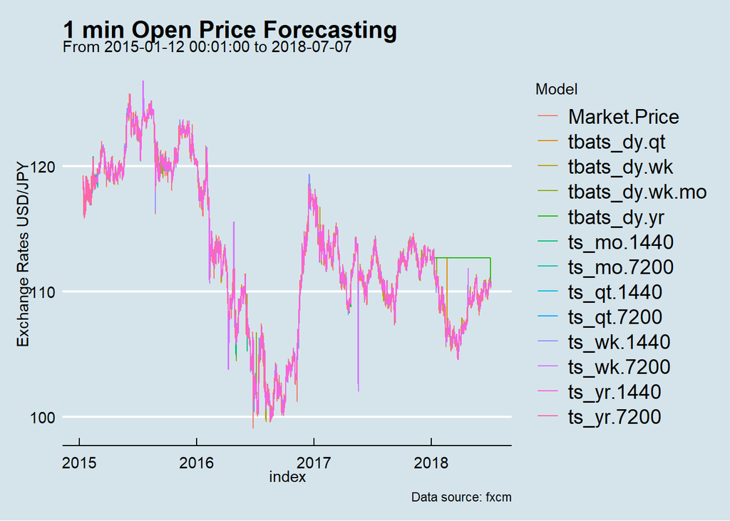

```r
## https://www.r-graph-gallery.com/line-chart-several-groups-ggplot2.html
p1 <- grph %>%
  ggplot(aes(x = index, y = open, group = Model, color = Model)) +
  geom_line() +
  #scale_colour_gradient2_tableau(palette = names(palettes)[1]) + #first palettes list in name
  #scale_color_viridis(discrete = TRUE) +
  labs(title = '1 min Open Price Forecasting',
       subtitle = paste('From', range(unique(grph$index))[1L], 'to', range(unique(grph$index))[2L]),
       caption = "Data source: fxcm") +
  ylab('Exchange Rates USD/JPY') +
  theme_economist() +
  #scale_color_economist() +
  ##scale_fill_manual(values = tableau_colours) +
  #scale_color_brewer(tableau_colours) +
  #scale_color_jcolors(palette = palettes2$`Tableau 20`$value) + #choose color set among palettes
  #theme(axis.text.x = element_text(hjust = c(0, 0.5, 0.5, 0.5, 1))) +
  theme(legend.position = 'right')

#ggplotly(p1)
p1
```

##### 5.1.1.1.3 High Price

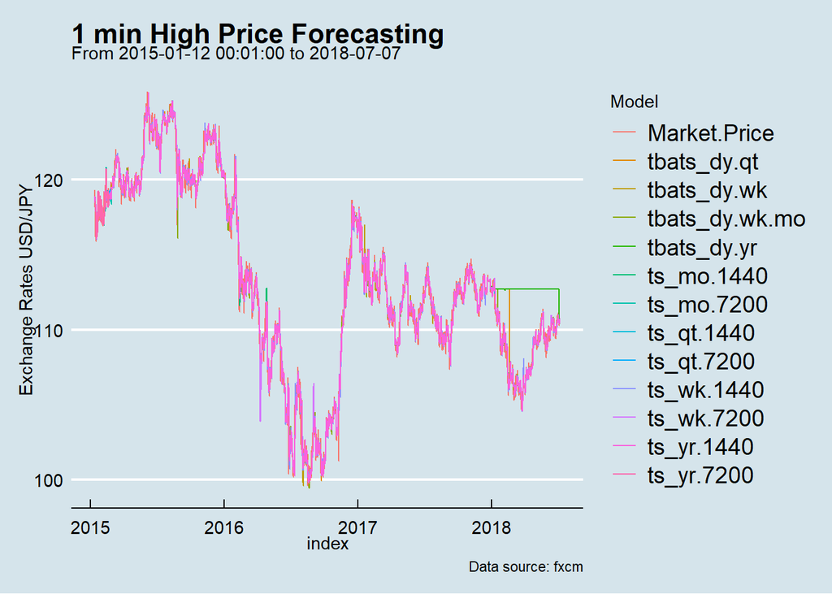

```r
rm(p1)

## https://www.r-graph-gallery.com/line-chart-several-groups-ggplot2.html
p2 <- grph %>%
  ggplot(aes(x = index, y = high, group = Model, color = Model)) +
  geom_line() +
  #scale_color_viridis(discrete = TRUE) +
  labs(title = '1 min High Price Forecasting',
       subtitle = paste('From', range(unique(grph$index))[1L], 'to', range(unique(grph$index))[2L]),
       caption = "Data source: fxcm") +
  ylab('Exchange Rates USD/JPY') +
  theme_economist() +
  #scale_color_economist() +
  #theme(axis.text.x = element_text(hjust = c(0, 0.5, 0.5, 0.5, 1))) +
  theme(legend.position = 'right')

#ggplotly(p2)
p2
```

##### 5.1.1.1.4 Low Price

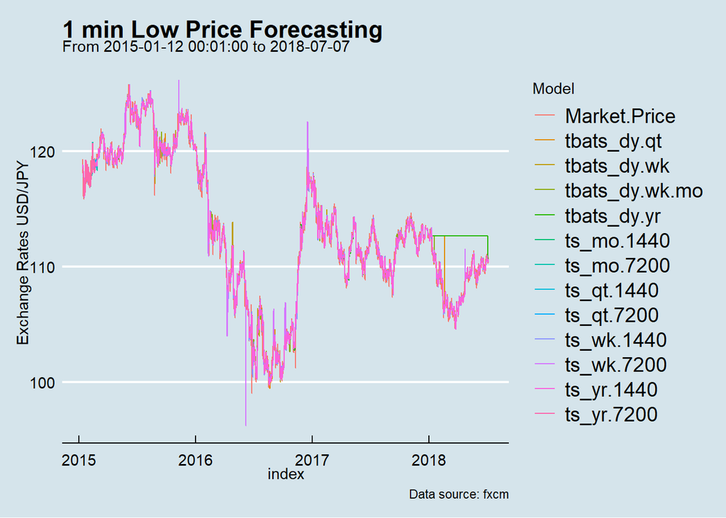

```r
rm(p2)

## https://www.r-graph-gallery.com/line-chart-several-groups-ggplot2.html
p3 <- grph %>%
  ggplot(aes(x = index, y = low, group = Model, color = Model)) +
  geom_line() +
  #scale_color_viridis(discrete = TRUE) +
  labs(title = '1 min Low Price Forecasting',
       subtitle = paste('From', range(unique(grph$index))[1], 'to', range(unique(grph$index))[2]),
       caption = "Data source: fxcm") +
  ylab('Exchange Rates USD/JPY') +
  theme_economist() +
  #scale_color_economist() +
  #theme(axis.text.x = element_text(hjust = c(0, 0.5, 0.5, 0.5, 1))) +
  theme(legend.position = 'right')

#ggplotly(p3)
p3
```

##### 5.1.1.1.5 Close Price

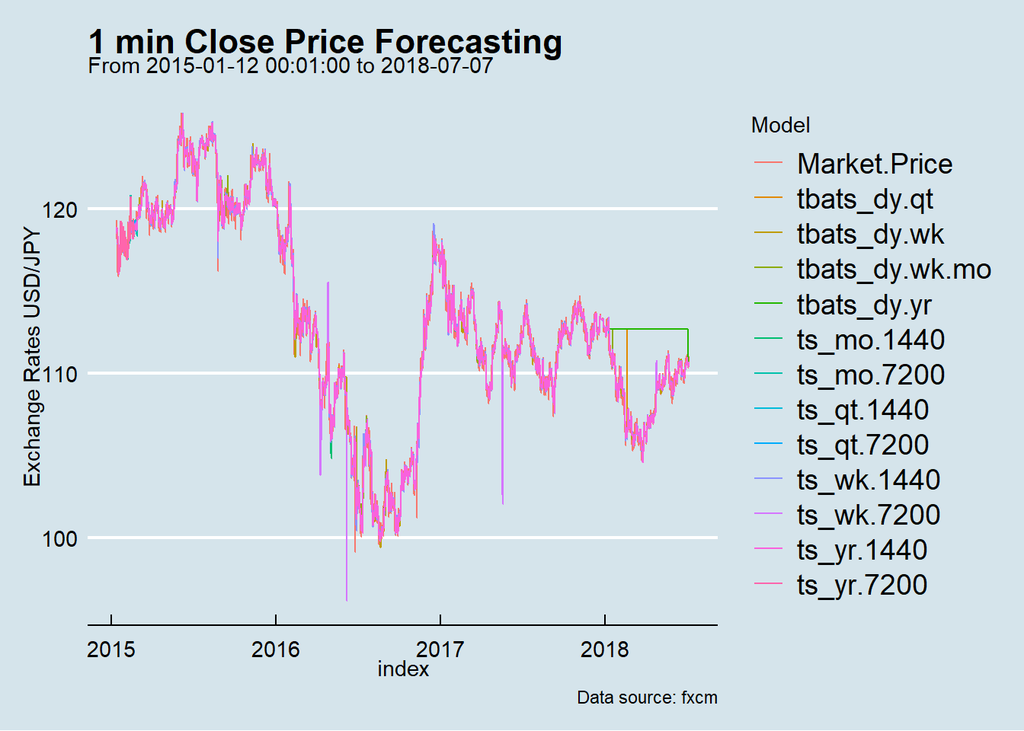

```r
rm(p3)

## https://www.r-graph-gallery.com/line-chart-several-groups-ggplot2.html
p4 <- grph %>%
  ggplot(aes(x = index, y = close, group = Model, color = Model)) +
  geom_line() +
  #scale_color_viridis(discrete = TRUE) +
  labs(title = '1 min Close Price Forecasting',
       subtitle = paste('From', range(unique(grph$index))[1], 'to', range(unique(grph$index))[2]),
       caption = "Data source: fxcm") +
  ylab('Exchange Rates USD/JPY') +
  theme_economist() +
  #scale_color_economist() +
  #theme(axis.text.x = element_text(hjust = c(0, 0.5, 0.5, 0.5, 1))) +
  theme(legend.position = 'right')

#ggplotly(p4)
p4
```

#### 5.1.1.2 MSE Table

Below table compares the models.

```r
rm(p4)

mse1 <- seasonal_m1 %>%
  ddply(.(Model, Period), summarise,
        MSE.open = mean((open.Point.Forecast - open)^2, na.rm=TRUE),
        MSE.high = mean((high.Point.Forecast - high)^2, na.rm=TRUE),
        MSE.low = mean((low.Point.Forecast - low)^2, na.rm=TRUE),
        MSE.close = mean((close.Point.Forecast - close)^2, na.rm=TRUE),
        MSE.HLC = (MSE.high + MSE.low + MSE.close)/3,
        MSE.OHLC = (MSE.open + MSE.high + MSE.low + MSE.close)/4,
        n = length(index)) %>%
  as_tibble
```

```r
tb6 <- mse1 %>%
  mutate(
    MSE.open = ifelse(
      rank(MSE.open) <= 3,
      cell_spec(
        paste0(round(MSE.open, 7), ' (rank: ', sprintf('%1.f', rank(MSE.open)), ')'),
        'html', color = 'darkgoldenrod', bold = TRUE),
      cell_spec(
        paste0(round(MSE.open, 7), ' (rank: ', sprintf('%1.f', rank(MSE.open)), ')'),
        'html', color = 'grey', italic = TRUE)),
    MSE.high = ifelse(
      rank(MSE.high) <= 3,
      cell_spec(
        paste0(round(MSE.high, 7), ' (rank: ', sprintf('%1.f', rank(MSE.high)), ')'),
        'html', color = 'darkgoldenrod', bold = TRUE),
      cell_spec(
        paste0(round(MSE.high, 7), ' (rank: ', sprintf('%1.f', rank(MSE.high)), ')'),
        'html', color = 'grey', italic = TRUE)),
    MSE.low = ifelse(
      rank(MSE.low) <= 3,
      cell_spec(
        paste0(round(MSE.low, 7), ' (rank: ', sprintf('%1.f', rank(MSE.low)), ')'),
        'html', color = 'darkgoldenrod', bold = TRUE),
      cell_spec(
        paste0(round(MSE.low, 7), ' (rank: ', sprintf('%1.f', rank(MSE.low)), ')'),
        'html', color = 'grey', italic = TRUE)),
    MSE.close = ifelse(
      rank(MSE.close) <= 3,
      cell_spec(
        paste0(round(MSE.close, 7), ' (rank: ', sprintf('%1.f', rank(MSE.close)), ')'),
        'html', color = 'darkgoldenrod', bold = TRUE),
      cell_spec(
        paste0(round(MSE.close, 7), ' (rank: ', sprintf('%1.f', rank(MSE.close)), ')'),
        'html', color = 'grey', italic = TRUE)),
    MSE.HLC = ifelse(
      rank(MSE.HLC) <= 3,
      cell_spec(
        paste0(round(MSE.HLC, 7), ' (rank: ', sprintf('%1.f', rank(MSE.HLC)), ')'),
        'html', color = 'darkgoldenrod', bold = TRUE),
      cell_spec(
        paste0(round(MSE.HLC, 7), ' (rank: ', sprintf('%1.f', rank(MSE.HLC)), ')'),
        'html', color = 'grey', italic = TRUE)),
    MSE.OHLC = ifelse(
      rank(MSE.OHLC) <= 3,
      cell_spec(
        paste0(round(MSE.OHLC, 7), ' (rank: ', sprintf('%1.f', rank(MSE.OHLC)), ')'),
        'html', color = 'darkgoldenrod', bold = TRUE),
      cell_spec(
        paste0(round(MSE.OHLC, 7), ' (rank: ', sprintf('%1.f', rank(MSE.OHLC)), ')'),
        'html', color = 'grey', italic = TRUE))) %>%
  kbl('html', caption = 'MSE of Seasonal Daily 1440 minutes ETS Model (Accumulated Period from Weekly)', escape = FALSE) %>%
  ## https://www.w3schools.com/cssref/css_colors.asp
  row_spec(0, background = 'DimGrey') %>%
  column_spec(1, background = 'CornflowerBlue') %>%
  column_spec(2, background = 'DarkGrey') %>%
  column_spec(3, background = 'Gainsboro') %>%
  column_spec(4, background = 'LightGray') %>%
  column_spec(5, background = 'Gainsboro') %>%
  column_spec(6, background = 'LightGray') %>%
  column_spec(7, background = 'Gainsboro') %>%
  column_spec(8, background = 'LightGray') %>%
  column_spec(9, background = 'LightSlateGrey') %>%
  kable_styling(bootstrap_options = c('striped', 'hover', 'condensed', 'responsive')) %>%
  kable_material(full_width = FALSE) %>% ##`full_width = FALSE` will auto adjust every single columns width to fit the table full width.
  scroll_box(width = '100%')#, height = '400px')

rm(mse1)
tb6
```

MSE of Seasonal Daily 1440 minutes ETS Model (Accumulated Period from Weekly)

| Model | Period | MSE.open | MSE.high | MSE.low | MSE.close | MSE.HLC | MSE.OHLC | n |
| --- | --- | --- | --- | --- | --- | --- | --- | --- |
| tbats | dy.qt | 0.5935084 (rank: 11) | 0.5946396 (rank: 11) | 0.593577 (rank: 11) | 0.59344 (rank: 11) | 0.5938855 (rank: 11) | 0.5937912 (rank: 11) | 1298880 |
| tbats | dy.wk | 0.2331241 (rank: 1) | 0.2305384 (rank: 1) | 0.2331357 (rank: 1) | 0.2415673 (rank: 4) | 0.2350805 (rank: 2) | 0.2345914 (rank: 1) | 1298880 |
| tbats | dy.wk.mo | 0.2585134 (rank: 6) | 0.2531527 (rank: 7) | 0.2511519 (rank: 6) | 0.2468493 (rank: 5) | 0.2503846 (rank: 6) | 0.2524168 (rank: 6) | 1287360 |
| tbats | dy.yr | 2.992332 (rank: 12) | 3.0002451 (rank: 12) | 2.989127 (rank: 12) | 3.0017416 (rank: 12) | 2.9970379 (rank: 12) | 2.9958614 (rank: 12) | 1298880 |
| ts | mo.1440 | 0.238598 (rank: 4) | 0.2372364 (rank: 4) | 0.2349181 (rank: 4) | 0.2378324 (rank: 3) | 0.2366623 (rank: 4) | 0.2371462 (rank: 4) | 1298880 |
| ts | mo.7200 | 0.3134664 (rank: 8) | 0.3146787 (rank: 8) | 0.3119626 (rank: 8) | 0.3142609 (rank: 7) | 0.3136341 (rank: 8) | 0.3135922 (rank: 8) | 244800 |
| ts | qt.1440 | 0.2355912 (rank: 2) | 0.2357561 (rank: 2) | 0.2346795 (rank: 2) | 0.234693 (rank: 1) | 0.2350429 (rank: 1) | 0.2351799 (rank: 2) | 1298880 |
| ts | qt.7200 | 0.3156878 (rank: 9) | 0.3167276 (rank: 9) | 0.3144045 (rank: 9) | 0.3168899 (rank: 8) | 0.3160073 (rank: 9) | 0.3159275 (rank: 9) | 223200 |
| ts | wk.1440 | 0.2525562 (rank: 5) | 0.2483678 (rank: 6) | 0.2491352 (rank: 5) | 0.2490372 (rank: 6) | 0.2488467 (rank: 5) | 0.2497741 (rank: 5) | 1298880 |
| ts | wk.7200 | 0.2850686 (rank: 7) | 0.2391797 (rank: 5) | 0.3065442 (rank: 7) | 0.32009 (rank: 9) | 0.2886046 (rank: 7) | 0.2877206 (rank: 7) | 6494400 |
| ts | yr.1440 | 0.2357672 (rank: 3) | 0.2359108 (rank: 3) | 0.2349109 (rank: 3) | 0.2348683 (rank: 2) | 0.23523 (rank: 3) | 0.2353643 (rank: 3) | 1298880 |
| ts | yr.7200 | 0.3342637 (rank: 10) | 0.3353777 (rank: 10) | 0.3327021 (rank: 10) | 0.335306 (rank: 10) | 0.3344619 (rank: 10) | 0.3344124 (rank: 10) | 208800 |

### 5.1.2 Interday Models

Here I summarize 1440 of 1 min data to be 1 day and choose the best fitted model. Below table compares the models.

```r
# mse2 <- seasonal_m1 %>%
#   ddply(.(Model, Period, index), summarise,
#         MSE.open = mean((open.Point.Forecast - open)^2, na.rm=TRUE),
#         MSE.high = mean((high.Point.Forecast - high)^2, na.rm=TRUE),
#         MSE.low = mean((low.Point.Forecast - low)^2, na.rm=TRUE),
#         MSE.close = mean((close.Point.Forecast - close)^2, na.rm=TRUE),
#         MSE.HLC = (MSE.high + MSE.low + MSE.close)/3,
#         MSE.OHLC = (MSE.open + MSE.high + MSE.low + MSE.close)/4,
#         n = length(index)) %>%
#   as_tibble

## https://tysonbarrett.com/jekyll/update/2019/10/06/datatable_memory/
## http://brooksandrew.github.io/simpleblog/articles/advanced-data-table/
seasonal_m1 <- data.table(seasonal_m1)
setorder(seasonal_m1, index)

open.accr <- seasonal_m1[, {
  open = open
  open.Point.Forecast = open.Point.Forecast
  .SD[, .(.N, open.mape = MAPE(open, open.Point.Forecast),
          open.smape = SMAPE(open, open.Point.Forecast),
          open.mse = MSE(open, open.Point.Forecast),
          open.rmse = RMSE(open, open.Point.Forecast)),
      by={index=as_date(index)}]},
  by=.(Model, Period)]

high.accr <- seasonal_m1[, {
  high = high
  high.Point.Forecast = high.Point.Forecast
  .SD[, .(.N, high.mape = MAPE(high, high.Point.Forecast),
          high.smape = SMAPE(high, high.Point.Forecast),
          high.mse = MSE(high, high.Point.Forecast),
          high.rmse = RMSE(high, high.Point.Forecast)),
      by={index=as_date(index)}]},
  by=.(Model, Period)]

low.accr <- seasonal_m1[, {
  low = low
  low.Point.Forecast = low.Point.Forecast
  .SD[, .(.N, low.mape = MAPE(low, low.Point.Forecast),
          low.smape = SMAPE(low, low.Point.Forecast),
          low.mse = MSE(low, low.Point.Forecast),
          low.rmse = RMSE(low, low.Point.Forecast)),
      by={index=as_date(index)}]},
  by=.(Model, Period)]

close.accr <- seasonal_m1[, {
  close = close
  close.Point.Forecast = close.Point.Forecast
  .SD[, .(.N, close.mape = MAPE(close, close.Point.Forecast),
          close.smape = SMAPE(close, close.Point.Forecast),
          close.mse = MSE(close, close.Point.Forecast),
          close.rmse = RMSE(close, close.Point.Forecast)),
      by={index=as_date(index)}]},
  by=.(Model, Period)]
```

```r
open.sm <- open.accr[, list(open.mape = mean(open.mape),
                            open.smape = mean(open.smape),
                            open.mse = mean(open.mse),
                            open.rmse = mean(open.rmse)),
                       by=.(Model, Period)]

high.sm <- high.accr[, list(high.mape = mean(high.mape),
                            high.smape = mean(high.smape),
                            high.mse = mean(high.mse),
                            high.rmse = mean(high.rmse)),
                       by=.(Model, Period)]

low.sm <- low.accr[, list(low.mape = mean(low.mape),
                          low.smape = mean(low.smape),
                          low.mse = mean(low.mse),
                          low.rmse = mean(low.rmse)),
                       by=.(Model, Period)]

close.sm <- close.accr[, list(close.mape = mean(close.mape),
                              close.smape = mean(close.smape),
                              close.mse = mean(close.mse),
                              close.rmse = mean(close.rmse)),
                       by=.(Model, Period)]

daily.sm <- join_all(list(open.sm, high.sm, low.sm, close.sm)) %>%
  tibble

saveRDS(daily.sm, 'data/fx/USDJPY/best_m.rds')
```

#### 5.1.2.1 Open Price

```r
daily.sm <- readRDS('data/fx/USDJPY/best_m.rds')

tb7 <- daily.sm %>%
  dplyr::select(contains(c('Model', 'Period', 'open'))) %>%
  mutate(
    open.mape = ifelse(
      rank(open.mape) <= 3,
      cell_spec(
        paste0(round(open.mape, 7), ' (rank: ', sprintf('%1.f', rank(open.mape)), ')'),
        'html', color = 'darkgoldenrod', bold = TRUE),
      cell_spec(
        paste0(round(open.mape, 7), ' (rank: ', sprintf('%1.f', rank(open.mape)), ')'),
        'html', color = 'grey', italic = TRUE)),
    open.smape = ifelse(
      rank(open.smape) <= 3,
      cell_spec(
        paste0(round(open.smape, 7), ' (rank: ', sprintf('%1.f', rank(open.smape)), ')'),
        'html', color = 'darkgoldenrod', bold = TRUE),
      cell_spec(
        paste0(round(open.smape, 7), ' (rank: ', sprintf('%1.f', rank(open.smape)), ')'),
        'html', color = 'grey', italic = TRUE)),
    open.mse = ifelse(
      rank(open.mse) <= 3,
      cell_spec(
        paste0(round(open.mse, 7), ' (rank: ', sprintf('%1.f', rank(open.mse)), ')'),
        'html', color = 'darkgoldenrod', bold = TRUE),
      cell_spec(
        paste0(round(open.mse, 7), ' (rank: ', sprintf('%1.f', rank(open.mse)), ')'),
        'html', color = 'grey', italic = TRUE)),
    open.rmse = ifelse(
      rank(open.rmse) <= 3,
      cell_spec(
        paste0(round(open.rmse, 7), ' (rank: ', sprintf('%1.f', rank(open.rmse)), ')'),
        'html', color = 'darkgoldenrod', bold = TRUE),
      cell_spec(
        paste0(round(open.rmse, 7), ' (rank: ', sprintf('%1.f', rank(open.rmse)), ')'),
        'html', color = 'grey', italic = TRUE))) %>%
  kbl('html', caption = 'Comparison of Models (1 min Open Price Summarised to 1 Day per Unit)', escape = FALSE) %>%
  ## https://www.w3schools.com/cssref/css_colors.asp
  row_spec(0, background = 'DimGrey') %>%
  column_spec(1, background = 'CornflowerBlue') %>%
  column_spec(2, background = 'DarkGrey') %>%
  column_spec(3, background = 'Gainsboro') %>%
  column_spec(4, background = 'LightGray') %>%
  column_spec(5, background = 'Gainsboro') %>%
  column_spec(6, background = 'LightGray') %>%
  kable_styling(bootstrap_options = c('striped', 'hover', 'condensed', 'responsive')) %>%
  kable_material(full_width = FALSE) %>% ##`full_width = FALSE` will auto adjust every single columns width to fit the table full width.
  scroll_box(width = '100%')#, height = '400px')

tb7
```

Comparison of Models (1 min Open Price Summarised to 1 Day per Unit)

| Model | Period | open.mape | open.smape | open.mse | open.rmse |
| --- | --- | --- | --- | --- | --- |
| tbats | dy.qt | 0.0038487 (rank: 8) | 0.0038663 (rank: 8) | 0.6615488 (rank: 11) | 0.4836051 (rank: 8) |
| tbats | dy.wk | 0.0031178 (rank: 2) | 0.0031203 (rank: 2) | 0.2951857 (rank: 4) | 0.4022059 (rank: 1) |
| tbats | dy.yr | 0.0078141 (rank: 12) | 0.007929 (rank: 12) | 3.0602275 (rank: 12) | 0.9279223 (rank: 12) |
| ts | mo.1440 | 0.0031302 (rank: 4) | 0.0031321 (rank: 4) | 0.2895257 (rank: 3) | 0.4044655 (rank: 4) |
| ts | mo.7200 | 0.0041186 (rank: 10) | 0.0041147 (rank: 10) | 0.425753 (rank: 9) | 0.5564735 (rank: 10) |
| ts | qt.1440 | 0.0031176 (rank: 1) | 0.0031195 (rank: 1) | 0.2870498 (rank: 1) | 0.4030116 (rank: 2) |
| ts | qt.7200 | 0.004058 (rank: 9) | 0.0040546 (rank: 9) | 0.42255 (rank: 8) | 0.5479559 (rank: 9) |
| ts | wk.1440 | 0.0032485 (rank: 7) | 0.0032503 (rank: 7) | 0.3038581 (rank: 5) | 0.4183746 (rank: 7) |
| ts | wk.7200 | 0.0031907 (rank: 6) | 0.0031914 (rank: 6) | 0.3388586 (rank: 7) | 0.412083 (rank: 6) |
| ts | yr.1440 | 0.0031196 (rank: 3) | 0.0031215 (rank: 3) | 0.2872197 (rank: 2) | 0.4032139 (rank: 3) |
| ts | yr.7200 | 0.0042881 (rank: 11) | 0.0042843 (rank: 11) | 0.4553046 (rank: 10) | 0.5785254 (rank: 11) |
| tbats | dy.wk.mo | 0.0031517 (rank: 5) | 0.003155 (rank: 5) | 0.3068028 (rank: 6) | 0.4058541 (rank: 5) |

#### 5.1.2.2 High Price

```r
tb8 <- daily.sm %>%
  dplyr::select(contains(c('Model', 'Period', 'high'))) %>%
  mutate(
    high.mape = ifelse(
      rank(high.mape) <= 3,
      cell_spec(
        paste0(round(high.mape, 7), ' (rank: ', sprintf('%1.f', rank(high.mape)), ')'),
        'html', color = 'darkgoldenrod', bold = TRUE),
      cell_spec(
        paste0(round(high.mape, 7), ' (rank: ', sprintf('%1.f', rank(high.mape)), ')'),
        'html', color = 'grey', italic = TRUE)),
    high.smape = ifelse(
      rank(high.smape) <= 3,
      cell_spec(
        paste0(round(high.smape, 7), ' (rank: ', sprintf('%1.f', rank(high.smape)), ')'),
        'html', color = 'darkgoldenrod', bold = TRUE),
      cell_spec(
        paste0(round(high.smape, 7), ' (rank: ', sprintf('%1.f', rank(high.smape)), ')'),
        'html', color = 'grey', italic = TRUE)),
    high.mse = ifelse(
      rank(high.mse) <= 3,
      cell_spec(
        paste0(round(high.mse, 7), ' (rank: ', sprintf('%1.f', rank(high.mse)), ')'),
        'html', color = 'darkgoldenrod', bold = TRUE),
      cell_spec(
        paste0(round(high.mse, 7), ' (rank: ', sprintf('%1.f', rank(high.mse)), ')'),
        'html', color = 'grey', italic = TRUE)),
    high.rmse = ifelse(
      rank(high.rmse) <= 3,
      cell_spec(
        paste0(round(high.rmse, 7), ' (rank: ', sprintf('%1.f', rank(high.rmse)), ')'),
        'html', color = 'darkgoldenrod', bold = TRUE),
      cell_spec(
        paste0(round(high.rmse, 7), ' (rank: ', sprintf('%1.f', rank(high.rmse)), ')'),
        'html', color = 'grey', italic = TRUE))) %>%
  kbl('html', caption = 'Comparison of Models (1 min High Price Summarised to 1 Day per Unit)', escape = FALSE) %>%
  ## https://www.w3schools.com/cssref/css_colors.asp
  row_spec(0, background = 'DimGrey') %>%
  column_spec(1, background = 'CornflowerBlue') %>%
  column_spec(2, background = 'DarkGrey') %>%
  column_spec(3, background = 'Gainsboro') %>%
  column_spec(4, background = 'LightGray') %>%
  column_spec(5, background = 'Gainsboro') %>%
  column_spec(6, background = 'LightGray') %>%
  kable_styling(bootstrap_options = c('striped', 'hover', 'condensed', 'responsive')) %>%
  kable_material(full_width = FALSE) %>% ##`full_width = FALSE` will auto adjust every single columns width to fit the table full width.
  scroll_box(width = '100%')#, height = '400px')

tb8
```

Comparison of Models (1 min High Price Summarised to 1 Day per Unit)

| Model | Period | high.mape | high.smape | high.mse | high.rmse |
| --- | --- | --- | --- | --- | --- |
| tbats | dy.qt | 0.0038673 (rank: 8) | 0.0038852 (rank: 8) | 0.6658388 (rank: 11) | 0.4855776 (rank: 8) |
| tbats | dy.wk | 0.0030783 (rank: 1) | 0.0030807 (rank: 1) | 0.2846739 (rank: 1) | 0.397453 (rank: 1) |
| tbats | dy.yr | 0.0078297 (rank: 12) | 0.0079453 (rank: 12) | 3.0739678 (rank: 12) | 0.9298084 (rank: 12) |
| ts | mo.1440 | 0.0031371 (rank: 5) | 0.0031392 (rank: 5) | 0.2918493 (rank: 4) | 0.4052568 (rank: 5) |
| ts | mo.7200 | 0.0041905 (rank: 10) | 0.0041868 (rank: 10) | 0.4366597 (rank: 9) | 0.5650381 (rank: 10) |
| ts | qt.1440 | 0.0031227 (rank: 3) | 0.0031248 (rank: 3) | 0.288908 (rank: 2) | 0.4035778 (rank: 3) |
| ts | qt.7200 | 0.004129 (rank: 9) | 0.0041259 (rank: 9) | 0.4333607 (rank: 8) | 0.5565739 (rank: 9) |
| ts | wk.1440 | 0.0032312 (rank: 7) | 0.0032334 (rank: 7) | 0.3002029 (rank: 6) | 0.4159632 (rank: 7) |
| ts | wk.7200 | 0.0031119 (rank: 2) | 0.0031138 (rank: 2) | 0.2986969 (rank: 5) | 0.401548 (rank: 2) |
| ts | yr.1440 | 0.0031252 (rank: 4) | 0.0031273 (rank: 4) | 0.2890714 (rank: 3) | 0.4038346 (rank: 4) |
| ts | yr.7200 | 0.0043671 (rank: 11) | 0.0043636 (rank: 11) | 0.467057 (rank: 10) | 0.5881937 (rank: 11) |
| tbats | dy.wk.mo | 0.0031592 (rank: 6) | 0.0031622 (rank: 6) | 0.3054827 (rank: 7) | 0.4065748 (rank: 6) |

#### 5.1.2.3 Low Price

```r
tb9 <- daily.sm %>%
  dplyr::select(contains(c('Model', 'Period', 'low'))) %>%
  mutate(
    low.mape = ifelse(
      rank(low.mape) <= 3,
      cell_spec(
        paste0(round(low.mape, 7), ' (rank: ', sprintf('%1.f', rank(low.mape)), ')'),
        'html', color = 'darkgoldenrod', bold = TRUE),
      cell_spec(
        paste0(round(low.mape, 7), ' (rank: ', sprintf('%1.f', rank(low.mape)), ')'),
        'html', color = 'grey', italic = TRUE)),
    low.smape = ifelse(
      rank(low.smape) <= 3,
      cell_spec(
        paste0(round(low.smape, 7), ' (rank: ', sprintf('%1.f', rank(low.smape)), ')'),
        'html', color = 'darkgoldenrod', bold = TRUE),
      cell_spec(
        paste0(round(low.smape, 7), ' (rank: ', sprintf('%1.f', rank(low.smape)), ')'),
        'html', color = 'grey', italic = TRUE)),
    low.mse = ifelse(
      rank(low.mse) <= 3,
      cell_spec(
        paste0(round(low.mse, 7), ' (rank: ', sprintf('%1.f', rank(low.mse)), ')'),
        'html', color = 'darkgoldenrod', bold = TRUE),
      cell_spec(
        paste0(round(low.mse, 7), ' (rank: ', sprintf('%1.f', rank(low.mse)), ')'),
        'html', color = 'grey', italic = TRUE)),
    low.rmse = ifelse(
      rank(low.rmse) <= 3,
      cell_spec(
        paste0(round(low.rmse, 7), ' (rank: ', sprintf('%1.f', rank(low.rmse)), ')'),
        'html', color = 'darkgoldenrod', bold = TRUE),
      cell_spec(
        paste0(round(low.rmse, 7), ' (rank: ', sprintf('%1.f', rank(low.rmse)), ')'),
        'html', color = 'grey', italic = TRUE))) %>%
  kbl('html', caption = 'Comparison of Models (1 min Open Price Summarised to 1 Day per Unit)', escape = FALSE) %>%
  ## https://www.w3schools.com/cssref/css_colors.asp
  row_spec(0, background = 'DimGrey') %>%
  column_spec(1, background = 'CornflowerBlue') %>%
  column_spec(2, background = 'DarkGrey') %>%
  column_spec(3, background = 'Gainsboro') %>%
  column_spec(4, background = 'LightGray') %>%
  column_spec(5, background = 'Gainsboro') %>%
  column_spec(6, background = 'LightGray') %>%
  kable_styling(bootstrap_options = c('striped', 'hover', 'condensed', 'responsive')) %>%
  kable_material(full_width = FALSE) %>% ##`full_width = FALSE` will auto adjust every single columns width to fit the table full width.
  scroll_box(width = '100%')#, height = '400px')

tb9
```

| Model | Period | low.mape | low.smape | low.mse | low.rmse |
| --- | --- | --- | --- | --- | --- |
| tbats | dy.qt | 0.0038604 (rank: 8) | 0.0038777 (rank: 8) | 0.6593377 (rank: 11) | 0.4847373 (rank: 8) |
| tbats | dy.wk | 0.0030658 (rank: 1) | 0.0030678 (rank: 1) | 0.2820305 (rank: 1) | 0.3962719 (rank: 1) |
| tbats | dy.yr | 0.0078086 (rank: 12) | 0.0079229 (rank: 12) | 3.0492512 (rank: 12) | 0.9272861 (rank: 12) |
| ts | mo.1440 | 0.0031155 (rank: 3) | 0.0031171 (rank: 3) | 0.2833452 (rank: 4) | 0.4027251 (rank: 3) |
| ts | mo.7200 | 0.0040769 (rank: 10) | 0.0040725 (rank: 10) | 0.4221267 (rank: 9) | 0.5517966 (rank: 10) |
| ts | qt.1440 | 0.0031147 (rank: 2) | 0.0031162 (rank: 2) | 0.2829726 (rank: 2) | 0.4026439 (rank: 2) |
| ts | qt.7200 | 0.0039968 (rank: 9) | 0.0039929 (rank: 9) | 0.4190357 (rank: 8) | 0.5412921 (rank: 9) |
| ts | wk.1440 | 0.0032298 (rank: 6) | 0.0032312 (rank: 6) | 0.2968221 (rank: 5) | 0.4159053 (rank: 6) |
| ts | wk.7200 | 0.0032465 (rank: 7) | 0.0032471 (rank: 7) | 0.3657361 (rank: 7) | 0.4186519 (rank: 7) |
| ts | yr.1440 | 0.0031173 (rank: 4) | 0.0031188 (rank: 4) | 0.2831797 (rank: 3) | 0.4029436 (rank: 4) |
| ts | yr.7200 | 0.0042393 (rank: 11) | 0.004235 (rank: 11) | 0.4522995 (rank: 10) | 0.5732734 (rank: 11) |
| tbats | dy.wk.mo | 0.0031814 (rank: 5) | 0.0031842 (rank: 5) | 0.3030913 (rank: 6) | 0.4089394 (rank: 5) |

#### 5.1.2.4 Close Price

```r
tb10 <- daily.sm %>%
  dplyr::select(contains(c('Model', 'Period', 'close'))) %>%
  mutate(
    close.mape = ifelse(
      rank(close.mape) <= 3,
      cell_spec(
        paste0(round(close.mape, 7), ' (rank: ', sprintf('%1.f', rank(close.mape)), ')'),
        'html', color = 'darkgoldenrod', bold = TRUE),
      cell_spec(
        paste0(round(close.mape, 7), ' (rank: ', sprintf('%1.f', rank(close.mape)), ')'),
        'html', color = 'grey', italic = TRUE)),
    close.smape = ifelse(
      rank(close.smape) <= 3,
      cell_spec(
        paste0(round(close.smape, 7), ' (rank: ', sprintf('%1.f', rank(close.smape)), ')'),
        'html', color = 'darkgoldenrod', bold = TRUE),
      cell_spec(
        paste0(round(close.smape, 7), ' (rank: ', sprintf('%1.f', rank(close.smape)), ')'),
        'html', color = 'grey', italic = TRUE)),
    close.mse = ifelse(
      rank(close.mse) <= 3,
      cell_spec(
        paste0(round(close.mse, 7), ' (rank: ', sprintf('%1.f', rank(close.mse)), ')'),
        'html', color = 'darkgoldenrod', bold = TRUE),
      cell_spec(
        paste0(round(close.mse, 7), ' (rank: ', sprintf('%1.f', rank(close.mse)), ')'),
        'html', color = 'grey', italic = TRUE)),
    close.rmse = ifelse(
      rank(close.rmse) <= 3,
      cell_spec(
        paste0(round(close.rmse, 7), ' (rank: ', sprintf('%1.f', rank(close.rmse)), ')'),
        'html', color = 'darkgoldenrod', bold = TRUE),
      cell_spec(
        paste0(round(close.rmse, 7), ' (rank: ', sprintf('%1.f', rank(close.rmse)), ')'),
        'html', color = 'grey', italic = TRUE))) %>%
  kbl('html', caption = 'Comparison of Models (1 min Close Price Summarised to 1 Day per Unit)', escape = FALSE) %>%
  ## https://www.w3schools.com/cssref/css_colors.asp
  row_spec(0, background = 'DimGrey') %>%
  column_spec(1, background = 'CornflowerBlue') %>%
  column_spec(2, background = 'DarkGrey') %>%
  column_spec(3, background = 'Gainsboro') %>%
  column_spec(4, background = 'LightGray') %>%
  column_spec(5, background = 'Gainsboro') %>%
  column_spec(6, background = 'LightGray') %>%
  kable_styling(bootstrap_options = c('striped', 'hover', 'condensed', 'responsive')) %>%
  kable_material(full_width = FALSE) %>% ##`full_width = FALSE` will auto adjust every single columns width to fit the table full width.
  scroll_box(width = '100%')#, height = '400px')

tb10
```

Comparison of Models (1 min Close Price Summarised to 1 Day per Unit)

| Model | Period | close.mape | close.smape | close.mse | close.rmse |
| --- | --- | --- | --- | --- | --- |
| tbats | dy.qt | 0.0038503 (rank: 8) | 0.0038679 (rank: 8) | 0.6610232 (rank: 11) | 0.4837561 (rank: 8) |
| tbats | dy.wk | 0.003145 (rank: 5) | 0.0031473 (rank: 5) | 0.3015154 (rank: 6) | 0.4057309 (rank: 5) |
| tbats | dy.yr | 0.0078135 (rank: 12) | 0.0079289 (rank: 12) | 3.0682874 (rank: 12) | 0.9280099 (rank: 12) |
| ts | mo.1440 | 0.0031304 (rank: 4) | 0.003132 (rank: 4) | 0.2874381 (rank: 3) | 0.4044561 (rank: 4) |
| ts | mo.7200 | 0.0041607 (rank: 10) | 0.0041564 (rank: 10) | 0.4379246 (rank: 9) | 0.5616704 (rank: 10) |
| ts | qt.1440 | 0.0031164 (rank: 1) | 0.0031182 (rank: 1) | 0.284739 (rank: 1) | 0.4028578 (rank: 2) |
| ts | qt.7200 | 0.0040893 (rank: 9) | 0.0040855 (rank: 9) | 0.4356525 (rank: 8) | 0.5524039 (rank: 9) |
| ts | wk.1440 | 0.0032319 (rank: 7) | 0.0032337 (rank: 7) | 0.2995034 (rank: 5) | 0.4162795 (rank: 7) |
| ts | wk.7200 | 0.0031979 (rank: 6) | 0.0031966 (rank: 6) | 0.3632592 (rank: 7) | 0.4118763 (rank: 6) |
| ts | yr.1440 | 0.0031187 (rank: 2) | 0.0031205 (rank: 2) | 0.2849251 (rank: 2) | 0.403099 (rank: 3) |
| ts | yr.7200 | 0.0043391 (rank: 11) | 0.0043348 (rank: 11) | 0.4701278 (rank: 10) | 0.5850767 (rank: 11) |
| tbats | dy.wk.mo | 0.0031204 (rank: 3) | 0.0031234 (rank: 3) | 0.2948921 (rank: 4) | 0.4018679 (rank: 1) |

#### 5.1.2.5 Summary

```r
tb11 <- daily.sm %>%
  mutate(
    open.mape = ifelse(
      rank(open.mape) <= 3,
      cell_spec(
        paste0(round(open.mape, 7), ' (rank: ', sprintf('%1.f', rank(open.mape)), ')'),
        'html', color = 'darkgoldenrod', bold = TRUE),
      cell_spec(
        paste0(round(open.mape, 7), ' (rank: ', sprintf('%1.f', rank(open.mape)), ')'),
        'html', color = 'grey', italic = TRUE)),
    open.smape = ifelse(
      rank(open.smape) <= 3,
      cell_spec(
        paste0(round(open.smape, 7), ' (rank: ', sprintf('%1.f', rank(open.smape)), ')'),
        'html', color = 'darkgoldenrod', bold = TRUE),
      cell_spec(
        paste0(round(open.smape, 7), ' (rank: ', sprintf('%1.f', rank(open.smape)), ')'),
        'html', color = 'grey', italic = TRUE)),
    open.mse = ifelse(
      rank(open.mse) <= 3,
      cell_spec(
        paste0(round(open.mse, 7), ' (rank: ', sprintf('%1.f', rank(open.mse)), ')'),
        'html', color = 'darkgoldenrod', bold = TRUE),
      cell_spec(
        paste0(round(open.mse, 7), ' (rank: ', sprintf('%1.f', rank(open.mse)), ')'),
        'html', color = 'grey', italic = TRUE)),
    open.rmse = ifelse(
      rank(open.rmse) <= 3,
      cell_spec(
        paste0(round(open.rmse, 7), ' (rank: ', sprintf('%1.f', rank(open.rmse)), ')'),
        'html', color = 'darkgoldenrod', bold = TRUE),
      cell_spec(
        paste0(round(open.rmse, 7), ' (rank: ', sprintf('%1.f', rank(open.rmse)), ')'),
        'html', color = 'grey', italic = TRUE)),

    high.mape = ifelse(
      rank(high.mape) <= 3,
      cell_spec(
        paste0(round(high.mape, 7), ' (rank: ', sprintf('%1.f', rank(high.mape)), ')'),
        'html', color = 'darkgoldenrod', bold = TRUE),
      cell_spec(
        paste0(round(high.mape, 7), ' (rank: ', sprintf('%1.f', rank(high.mape)), ')'),
        'html', color = 'grey', italic = TRUE)),
    high.smape = ifelse(
      rank(high.smape) <= 3,
      cell_spec(
        paste0(round(high.smape, 7), ' (rank: ', sprintf('%1.f', rank(high.smape)), ')'),
        'html', color = 'darkgoldenrod', bold = TRUE),
      cell_spec(
        paste0(round(high.smape, 7), ' (rank: ', sprintf('%1.f', rank(high.smape)), ')'),
        'html', color = 'grey', italic = TRUE)),
    high.mse = ifelse(
      rank(high.mse) <= 3,
      cell_spec(
        paste0(round(high.mse, 7), ' (rank: ', sprintf('%1.f', rank(high.mse)), ')'),
        'html', color = 'darkgoldenrod', bold = TRUE),
      cell_spec(
        paste0(round(high.mse, 7), ' (rank: ', sprintf('%1.f', rank(high.mse)), ')'),
        'html', color = 'grey', italic = TRUE)),
    high.rmse = ifelse(
      rank(high.rmse) <= 3,
      cell_spec(
        paste0(round(high.rmse, 7), ' (rank: ', sprintf('%1.f', rank(high.rmse)), ')'),
        'html', color = 'darkgoldenrod', bold = TRUE),
      cell_spec(
        paste0(round(high.rmse, 7), ' (rank: ', sprintf('%1.f', rank(high.rmse)), ')'),
        'html', color = 'grey', italic = TRUE)),

    low.mape = ifelse(
      rank(low.mape) <= 3,
      cell_spec(
        paste0(round(low.mape, 7), ' (rank: ', sprintf('%1.f', rank(low.mape)), ')'),
        'html', color = 'darkgoldenrod', bold = TRUE),
      cell_spec(
        paste0(round(low.mape, 7), ' (rank: ', sprintf('%1.f', rank(low.mape)), ')'),
        'html', color = 'grey', italic = TRUE)),
    low.smape = ifelse(
      rank(low.smape) <= 3,
      cell_spec(
        paste0(round(low.smape, 7), ' (rank: ', sprintf('%1.f', rank(low.smape)), ')'),
        'html', color = 'darkgoldenrod', bold = TRUE),
      cell_spec(
        paste0(round(low.smape, 7), ' (rank: ', sprintf('%1.f', rank(low.smape)), ')'),
        'html', color = 'grey', italic = TRUE)),
    low.mse = ifelse(
      rank(low.mse) <= 3,
      cell_spec(
        paste0(round(low.mse, 7), ' (rank: ', sprintf('%1.f', rank(low.mse)), ')'),
        'html', color = 'darkgoldenrod', bold = TRUE),
      cell_spec(
        paste0(round(low.mse, 7), ' (rank: ', sprintf('%1.f', rank(low.mse)), ')'),
        'html', color = 'grey', italic = TRUE)),
    low.rmse = ifelse(
      rank(low.rmse) <= 3,
      cell_spec(
        paste0(round(low.rmse, 7), ' (rank: ', sprintf('%1.f', rank(low.rmse)), ')'),
        'html', color = 'darkgoldenrod', bold = TRUE),
      cell_spec(
        paste0(round(low.rmse, 7), ' (rank: ', sprintf('%1.f', rank(low.rmse)), ')'),
        'html', color = 'grey', italic = TRUE)),

    close.mape = ifelse(
      rank(close.mape) <= 3,
      cell_spec(
        paste0(round(close.mape, 7), ' (rank: ', sprintf('%1.f', rank(close.mape)), ')'),
        'html', color = 'darkgoldenrod', bold = TRUE),
      cell_spec(
        paste0(round(close.mape, 7), ' (rank: ', sprintf('%1.f', rank(close.mape)), ')'),
        'html', color = 'grey', italic = TRUE)),
    close.smape = ifelse(
      rank(close.smape) <= 3,
      cell_spec(
        paste0(round(close.smape, 7), ' (rank: ', sprintf('%1.f', rank(close.smape)), ')'),
        'html', color = 'darkgoldenrod', bold = TRUE),
      cell_spec(
        paste0(round(close.smape, 7), ' (rank: ', sprintf('%1.f', rank(close.smape)), ')'),
        'html', color = 'grey', italic = TRUE)),
    close.mse = ifelse(
      rank(close.mse) <= 3,
      cell_spec(
        paste0(round(close.mse, 7), ' (rank: ', sprintf('%1.f', rank(close.mse)), ')'),
        'html', color = 'darkgoldenrod', bold = TRUE),
      cell_spec(
        paste0(round(close.mse, 7), ' (rank: ', sprintf('%1.f', rank(close.mse)), ')'),
        'html', color = 'grey', italic = TRUE)),
    close.rmse = ifelse(
      rank(close.rmse) <= 3,
      cell_spec(
        paste0(round(close.rmse, 7), ' (rank: ', sprintf('%1.f', rank(close.rmse)), ')'),
        'html', color = 'darkgoldenrod', bold = TRUE),
      cell_spec(
        paste0(round(close.rmse, 7), ' (rank: ', sprintf('%1.f', rank(close.rmse)), ')'),
        'html', color = 'grey', italic = TRUE))) %>%
  kbl('html', caption = 'Comparison of Models (1 min summarised to 1 day per unit)', escape = FALSE) %>%
  ## https://www.w3schools.com/cssref/css_colors.asp
  row_spec(0, background = 'DimGrey') %>%
  column_spec(1, background = 'CornflowerBlue') %>%
  column_spec(2, background = 'DarkGrey') %>%
  #column_spec(3, background = 'LightSlateGrey') %>%
  column_spec(3, background = 'LightGray') %>%
  column_spec(4, background = 'Gainsboro') %>%
  column_spec(5, background = 'LightGray') %>%
  column_spec(6, background = 'Gainsboro') %>%
  column_spec(7, background = 'LightGray') %>%
  column_spec(8, background = 'Gainsboro') %>%
  column_spec(9, background = 'LightGray') %>%
  column_spec(10, background = 'Gainsboro') %>%
  column_spec(11, background = 'LightGray') %>%
  column_spec(12, background = 'Gainsboro') %>%
  column_spec(13, background = 'LightGray') %>%
  column_spec(14, background = 'Gainsboro') %>%
  column_spec(15, background = 'LightGray') %>%
  column_spec(16, background = 'Gainsboro') %>%
  column_spec(17, background = 'LightGray') %>%
  column_spec(18, background = 'Gainsboro') %>%
  kable_styling(bootstrap_options = c('striped', 'hover', 'condensed', 'responsive')) %>%
  kable_material(full_width = FALSE) %>% ##`full_width = FALSE` will auto adjust every single columns width to fit the table full width.
  scroll_box(width = '100%')#, height = '400px')

tb11
```

Comparison of Models (1 min summarised to 1 day per unit)

| Model | Period | open.mape | open.smape | open.mse | open.rmse | high.mape | high.smape | high.mse | high.rmse | low.mape | low.smape | low.mse | low.rmse | close.mape | close.smape | close.mse | close.rmse |
| --- | --- | --- | --- | --- | --- | --- | --- | --- | --- | --- | --- | --- | --- | --- | --- | --- | --- |
| tbats | dy.qt | 0.0038487 (rank: 8) | 0.0038663 (rank: 8) | 0.6615488 (rank: 11) | 0.4836051 (rank: 8) | 0.0038673 (rank: 8) | 0.0038852 (rank: 8) | 0.6658388 (rank: 11) | 0.4855776 (rank: 8) | 0.0038604 (rank: 8) | 0.0038777 (rank: 8) | 0.6593377 (rank: 11) | 0.4847373 (rank: 8) | 0.0038503 (rank: 8) | 0.0038679 (rank: 8) | 0.6610232 (rank: 11) | 0.4837561 (rank: 8) |
| tbats | dy.wk | 0.0031178 (rank: 2) | 0.0031203 (rank: 2) | 0.2951857 (rank: 4) | 0.4022059 (rank: 1) | 0.0030783 (rank: 1) | 0.0030807 (rank: 1) | 0.2846739 (rank: 1) | 0.397453 (rank: 1) | 0.0030658 (rank: 1) | 0.0030678 (rank: 1) | 0.2820305 (rank: 1) | 0.3962719 (rank: 1) | 0.003145 (rank: 5) | 0.0031473 (rank: 5) | 0.3015154 (rank: 6) | 0.4057309 (rank: 5) |
| tbats | dy.yr | 0.0078141 (rank: 12) | 0.007929 (rank: 12) | 3.0602275 (rank: 12) | 0.9279223 (rank: 12) | 0.0078297 (rank: 12) | 0.0079453 (rank: 12) | 3.0739678 (rank: 12) | 0.9298084 (rank: 12) | 0.0078086 (rank: 12) | 0.0079229 (rank: 12) | 3.0492512 (rank: 12) | 0.9272861 (rank: 12) | 0.0078135 (rank: 12) | 0.0079289 (rank: 12) | 3.0682874 (rank: 12) | 0.9280099 (rank: 12) |
| ts | mo.1440 | 0.0031302 (rank: 4) | 0.0031321 (rank: 4) | 0.2895257 (rank: 3) | 0.4044655 (rank: 4) | 0.0031371 (rank: 5) | 0.0031392 (rank: 5) | 0.2918493 (rank: 4) | 0.4052568 (rank: 5) | 0.0031155 (rank: 3) | 0.0031171 (rank: 3) | 0.2833452 (rank: 4) | 0.4027251 (rank: 3) | 0.0031304 (rank: 4) | 0.003132 (rank: 4) | 0.2874381 (rank: 3) | 0.4044561 (rank: 4) |
| ts | mo.7200 | 0.0041186 (rank: 10) | 0.0041147 (rank: 10) | 0.425753 (rank: 9) | 0.5564735 (rank: 10) | 0.0041905 (rank: 10) | 0.0041868 (rank: 10) | 0.4366597 (rank: 9) | 0.5650381 (rank: 10) | 0.0040769 (rank: 10) | 0.0040725 (rank: 10) | 0.4221267 (rank: 9) | 0.5517966 (rank: 10) | 0.0041607 (rank: 10) | 0.0041564 (rank: 10) | 0.4379246 (rank: 9) | 0.5616704 (rank: 10) |
| ts | qt.1440 | 0.0031176 (rank: 1) | 0.0031195 (rank: 1) | 0.2870498 (rank: 1) | 0.4030116 (rank: 2) | 0.0031227 (rank: 3) | 0.0031248 (rank: 3) | 0.288908 (rank: 2) | 0.4035778 (rank: 3) | 0.0031147 (rank: 2) | 0.0031162 (rank: 2) | 0.2829726 (rank: 2) | 0.4026439 (rank: 2) | 0.0031164 (rank: 1) | 0.0031182 (rank: 1) | 0.284739 (rank: 1) | 0.4028578 (rank: 2) |
| ts | qt.7200 | 0.004058 (rank: 9) | 0.0040546 (rank: 9) | 0.42255 (rank: 8) | 0.5479559 (rank: 9) | 0.004129 (rank: 9) | 0.0041259 (rank: 9) | 0.4333607 (rank: 8) | 0.5565739 (rank: 9) | 0.0039968 (rank: 9) | 0.0039929 (rank: 9) | 0.4190357 (rank: 8) | 0.5412921 (rank: 9) | 0.0040893 (rank: 9) | 0.0040855 (rank: 9) | 0.4356525 (rank: 8) | 0.5524039 (rank: 9) |
| ts | wk.1440 | 0.0032485 (rank: 7) | 0.0032503 (rank: 7) | 0.3038581 (rank: 5) | 0.4183746 (rank: 7) | 0.0032312 (rank: 7) | 0.0032334 (rank: 7) | 0.3002029 (rank: 6) | 0.4159632 (rank: 7) | 0.0032298 (rank: 6) | 0.0032312 (rank: 6) | 0.2968221 (rank: 5) | 0.4159053 (rank: 6) | 0.0032319 (rank: 7) | 0.0032337 (rank: 7) | 0.2995034 (rank: 5) | 0.4162795 (rank: 7) |
| ts | wk.7200 | 0.0031907 (rank: 6) | 0.0031914 (rank: 6) | 0.3388586 (rank: 7) | 0.412083 (rank: 6) | 0.0031119 (rank: 2) | 0.0031138 (rank: 2) | 0.2986969 (rank: 5) | 0.401548 (rank: 2) | 0.0032465 (rank: 7) | 0.0032471 (rank: 7) | 0.3657361 (rank: 7) | 0.4186519 (rank: 7) | 0.0031979 (rank: 6) | 0.0031966 (rank: 6) | 0.3632592 (rank: 7) | 0.4118763 (rank: 6) |
| ts | yr.1440 | 0.0031196 (rank: 3) | 0.0031215 (rank: 3) | 0.2872197 (rank: 2) | 0.4032139 (rank: 3) | 0.0031252 (rank: 4) | 0.0031273 (rank: 4) | 0.2890714 (rank: 3) | 0.4038346 (rank: 4) | 0.0031173 (rank: 4) | 0.0031188 (rank: 4) | 0.2831797 (rank: 3) | 0.4029436 (rank: 4) | 0.0031187 (rank: 2) | 0.0031205 (rank: 2) | 0.2849251 (rank: 2) | 0.403099 (rank: 3) |
| ts | yr.7200 | 0.0042881 (rank: 11) | 0.0042843 (rank: 11) | 0.4553046 (rank: 10) | 0.5785254 (rank: 11) | 0.0043671 (rank: 11) | 0.0043636 (rank: 11) | 0.467057 (rank: 10) | 0.5881937 (rank: 11) | 0.0042393 (rank: 11) | 0.004235 (rank: 11) | 0.4522995 (rank: 10) | 0.5732734 (rank: 11) | 0.0043391 (rank: 11) | 0.0043348 (rank: 11) | 0.4701278 (rank: 10) | 0.5850767 (rank: 11) |
| tbats | dy.wk.mo | 0.0031517 (rank: 5) | 0.003155 (rank: 5) | 0.3068028 (rank: 6) | 0.4058541 (rank: 5) | 0.0031592 (rank: 6) | 0.0031622 (rank: 6) | 0.3054827 (rank: 7) | 0.4065748 (rank: 6) | 0.0031814 (rank: 5) | 0.0031842 (rank: 5) | 0.3030913 (rank: 6) | 0.4089394 (rank: 5) | 0.0031204 (rank: 3) | 0.0031234 (rank: 3) | 0.2948921 (rank: 4) | 0.4018679 (rank: 1) |

Above table summarized the daily `mape`, `smape`, `mse` and `rmse` values and then summarized again the models (which is nested summarize due to daily settlement), we can interpret from above table :

- Weekly or `7200 mins` length’s dataset with `msts(seasonal.periods = c(1440, 7200)) %>% tbats %>% forecast(h = 1440)`.
- Quarterly length’s dataset with `tk_ts(frequency = 1440) %>% forecast(h=1440)`.
- Annum length’s dataset with `tk_ts(frequency = 1440) %>% forecast(h=1440)`.